# Environmental indicator analysis-Tilefish

**2 Months**

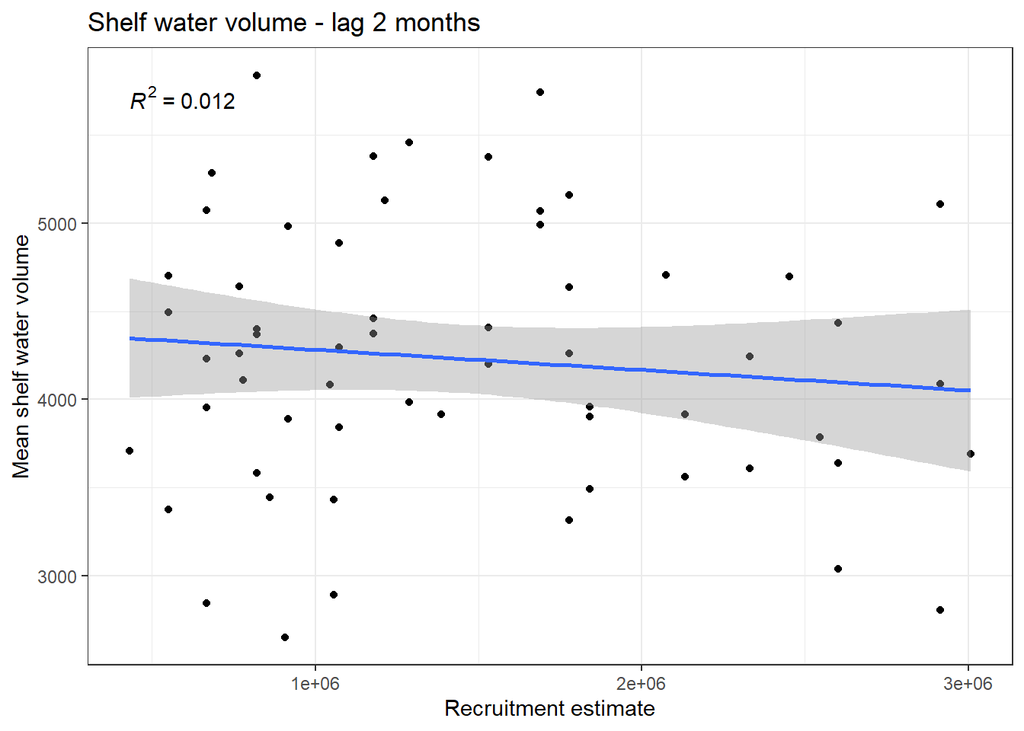

```r
## Shelf water volume 2 month lag
ggplot2::ggplot(df.join.shlf,
                aes(x=recruit_est, y=mean_v_lag2)) +
  geom_point(color = 'black') +
  stat_smooth(method = "lm",
              formula = y ~ x,
              geom = "smooth") +
  xlab('Recruitment estimate') +
  ylab('Mean shelf water volume') +
  labs(title = 'Shelf water volume - lag 2 months') +
  stat_cor(aes(label=..rr.label..)) +
  theme_bw()
```

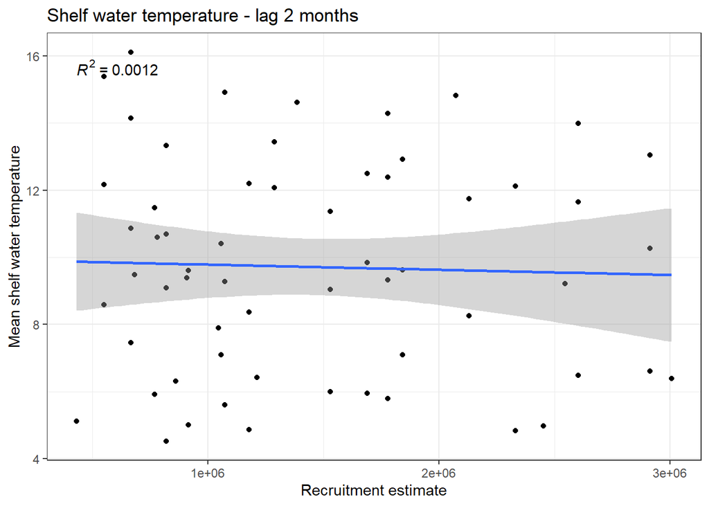

```r
## Shelf water temperature  2 month lag
ggplot2::ggplot(df.join.shlf,
                aes(x=recruit_est, y=mean_t_lag2)) +
  geom_point(color = 'black') +
  stat_smooth(method = "lm",
              formula = y ~ x,
              geom = "smooth") +
  xlab('Recruitment estimate') +
  ylab('Mean shelf water temperature') +
  labs(title = 'Shelf water temperature - lag 2 months') +
  stat_cor(aes(label=..rr.label..)) +
  theme_bw()
```

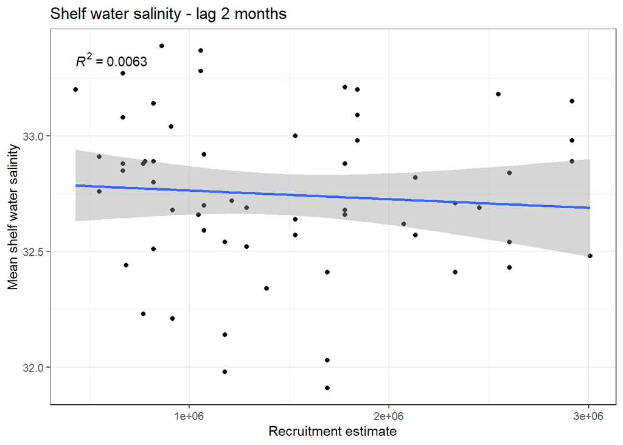

```r
## Shelf water salinity 2 month lag
ggplot2::ggplot(df.join.shlf,
                aes(x=recruit_est, y=mean_s_lag2)) +
  geom_point(color = 'black') +
  stat_smooth(method = "lm",
              formula = y ~ x,
              geom = "smooth") +
  xlab('Recruitment estimate') +
  ylab('Mean shelf water salinity') +
  labs(title = 'Shelf water salinity - lag 2 months') +
  stat_cor(aes(label=..rr.label..)) +
  theme_bw()
```

**3 Months**

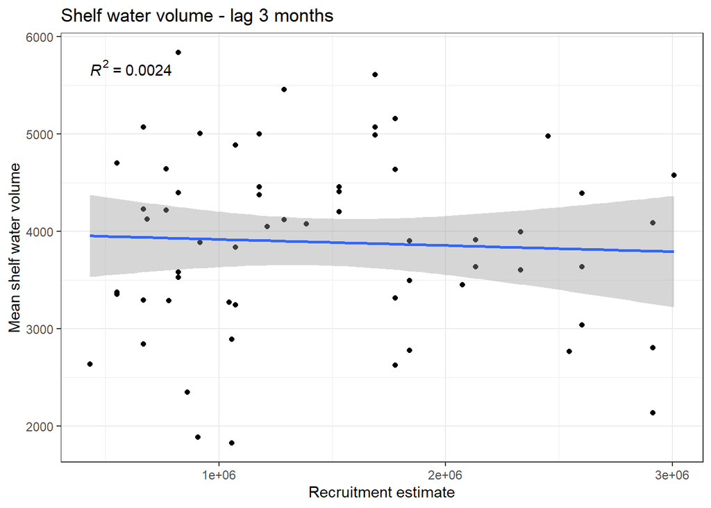

```r
## Shelf water volume 3 month lag
ggplot2::ggplot(df.join.shlf,
                aes(x=recruit_est, y=mean_v_lag3)) +
  geom_point(color = 'black') +
  stat_smooth(method = "lm",
              formula = y ~ x,
              geom = "smooth") +
  xlab('Recruitment estimate') +
  ylab('Mean shelf water volume') +
  labs(title = 'Shelf water volume - lag 3 months') +
  stat_cor(aes(label=..rr.label..)) +
  theme_bw()
```

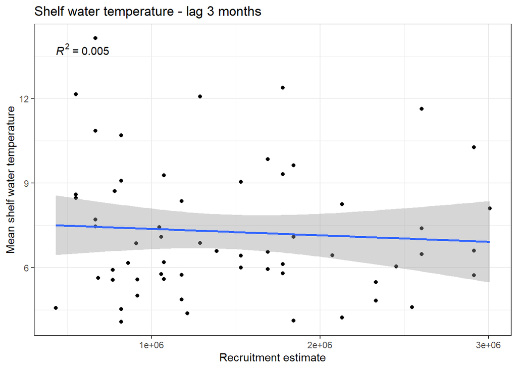

```r
## Shelf water temperature 3 month lag
ggplot2::ggplot(df.join.shlf,
                aes(x=recruit_est, y=mean_t_lag3)) +
  geom_point(color = 'black') +
  stat_smooth(method = "lm",
              formula = y ~ x,
              geom = "smooth") +
  xlab('Recruitment estimate') +
  ylab('Mean shelf water temperature') +
  labs(title = 'Shelf water temperature - lag 3 months') +
  stat_cor(aes(label=..rr.label..)) +
  theme_bw()
```

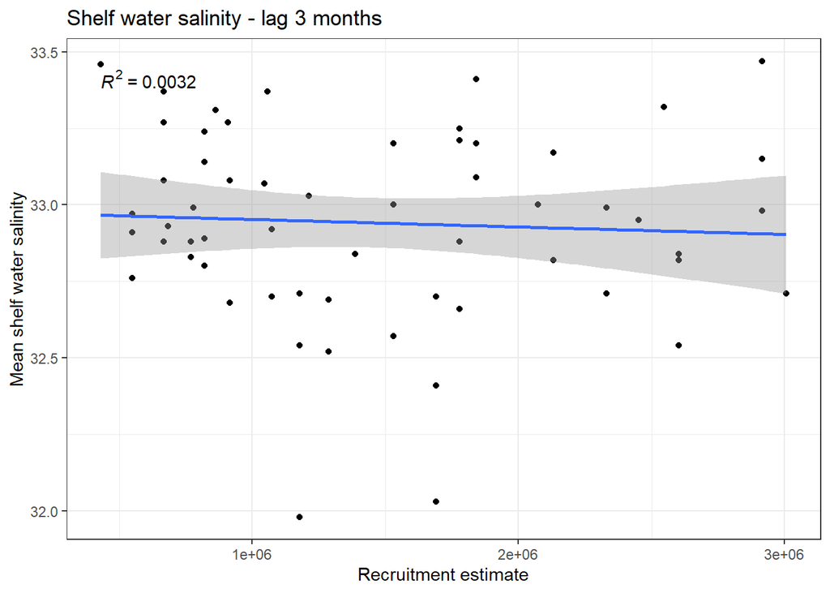

```r
## Shelf water salinity 3 month lag
ggplot2::ggplot(df.join.shlf,
                aes(x=recruit_est, y=mean_s_lag3)) +
  geom_point(color = 'black') +
  stat_smooth(method = "lm",
              formula = y ~ x,
              geom = "smooth") +
  xlab('Recruitment estimate') +
  ylab('Mean shelf water salinity') +
  labs(title = 'Shelf water salinity - lag 3 months') +
  stat_cor(aes(label=..rr.label..)) +
  theme_bw()
```

Annual

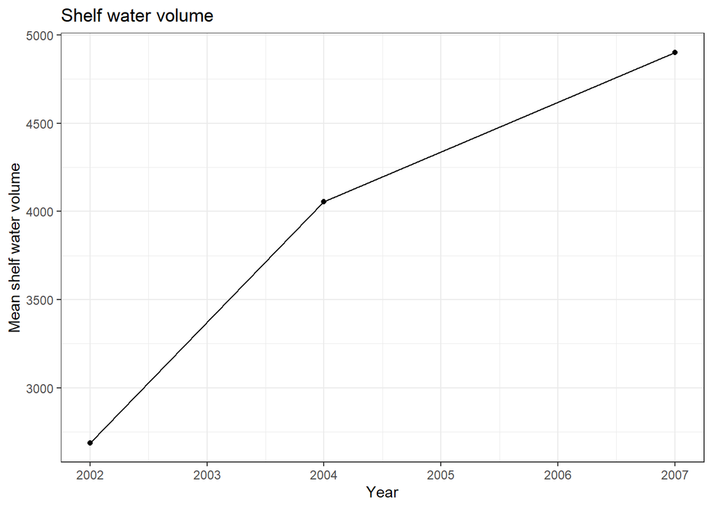

```r
# Create shw vol by year w/lag
df.lag = shlfvol %>%
  group_by(year, month) %>%
  summarise(mean_t = mean(ShW.T),
            mean_s = mean(ShW.S),
            mean_v = mean(ShW.Vol)) %>%
  mutate(mean_t_lag2 = lag(mean_t,2),
         mean_t_lag3 = lag(mean_t,3),
         mean_t_lag6 = lag(mean_t,6),
         mean_s_lag2 = lag(mean_s,2),
         mean_s_lag3 = lag(mean_s,3),
         mean_s_lag6 = lag(mean_s,6),
         mean_v_lag2 = lag(mean_v,2),
         mean_v_lag3 = lag(mean_v,3),
         mean_v_lag6 = lag(mean_v,6))
# Join in-situ bottom temps w/assessment recruitment estimate
df.join.shlf = dplyr::full_join(recruit, df.lag, by = join_by(year)) %>%
  dplyr::select(year, month, recruit_est, mean_t, mean_s, mean_v,
                mean_t_lag2, mean_s_lag2, mean_v_lag2,
                mean_t_lag3, mean_s_lag3, mean_v_lag3,
                mean_t_lag6, mean_s_lag6, mean_v_lag6) %>%
  tidyr::drop_na()

## Shelf water vol

ggplot2::ggplot(df.join.shlf,
                aes(x=year, y=mean_v)) +
  geom_point(color = 'black') +
  geom_line(color = 'black') +
  xlab('Year') +
  ylab('Mean shelf water volume') +
  labs(title = 'Shelf water volume') +
  theme_bw()
```

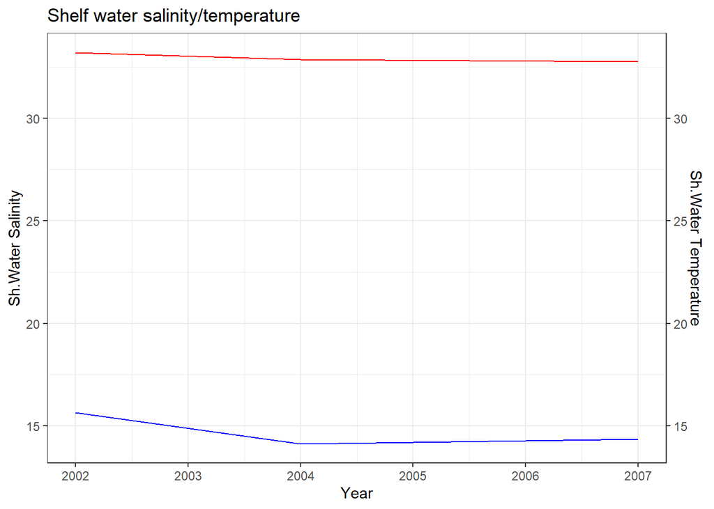

```r
ggplot2::ggplot() +
  geom_line(data = df.join.shlf, aes(x=year, y=mean_s), color = 'red') +
  geom_line(data = df.join.shlf,aes(x=year, y=mean_t*1), color = 'blue') +
  ylim(30.0,34.0) +
  scale_y_continuous(name = 'Sh.Water Salinity',
                      sec.axis = sec_axis(~./1, name = 'Sh.Water Temperature')) +
  xlab('Year') +
  labs(title = 'Shelf water salinity/temperature') +
  theme_bw()
```

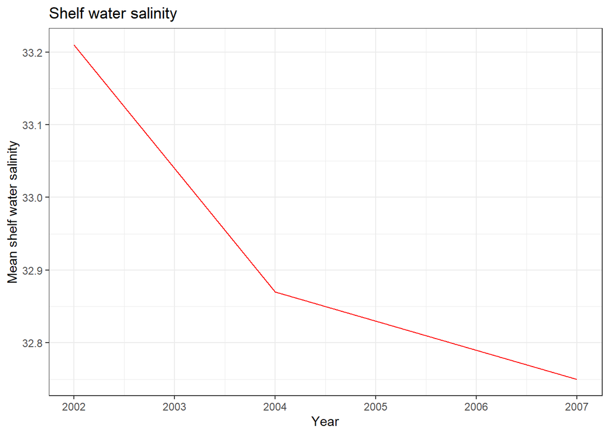

```r
ggplot2::ggplot() +
  geom_line(data = df.join.shlf, aes(x=year, y=mean_s), color = 'red') +
  xlab('Year') +
  ylab('Mean shelf water salinity') +
  labs(title = 'Shelf water salinity') +
  theme_bw()
```

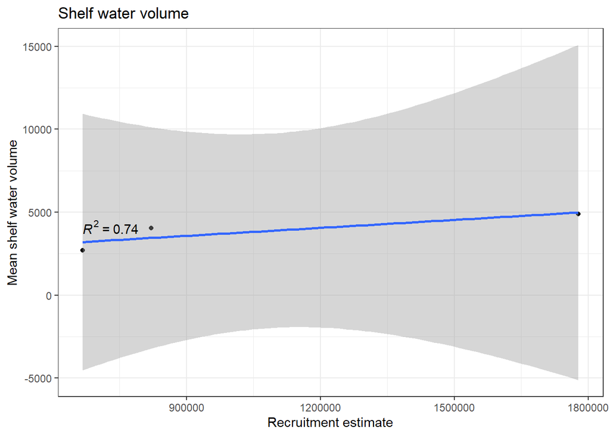

```r
## Shelf water vol no lag

ggplot2::ggplot(df.join.shlf,
                aes(x=recruit_est, y=mean_v)) +
  geom_point(color = 'black') +
  stat_smooth(method = "lm",
              formula = y ~ x,
              geom = "smooth") +
  xlab('Recruitment estimate') +
  ylab('Mean shelf water volume') +
  labs(title = 'Shelf water volume') +
  stat_cor(aes(label=..rr.label..)) +
  theme_bw()
```

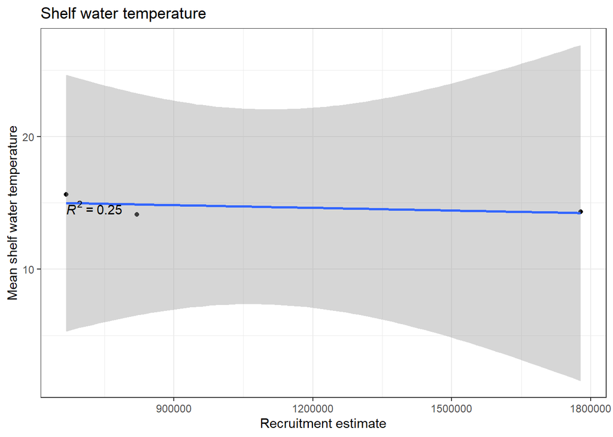

```r
## Shelf water temperature no lag
ggplot2::ggplot(df.join.shlf,
                aes(x=recruit_est, y=mean_t)) +
  geom_point(color = 'black') +
  stat_smooth(method = "lm",
              formula = y ~ x,
              geom = "smooth") +
  xlab('Recruitment estimate') +
  ylab('Mean shelf water temperature') +
  labs(title = 'Shelf water temperature') +
  stat_cor(aes(label=..rr.label..)) +
  theme_bw()
```

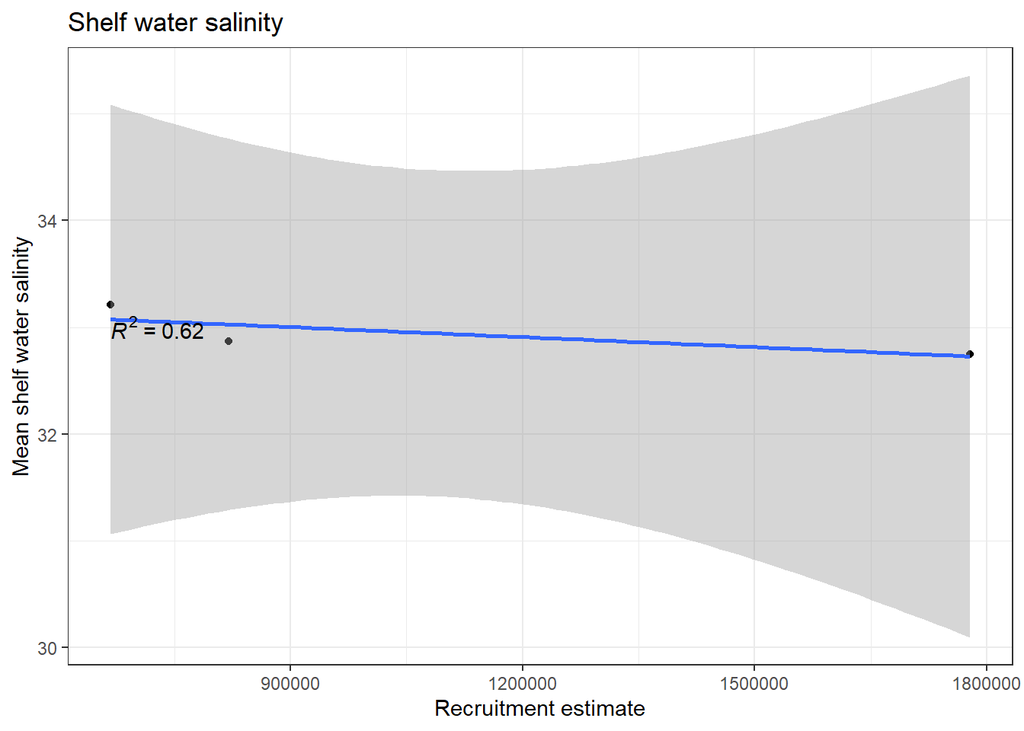

```r
## Shelf water salinity no lag
ggplot2::ggplot(df.join.shlf,
                aes(x=recruit_est, y=mean_s)) +
  geom_point(color = 'black') +
  stat_smooth(method = "lm",
              formula = y ~ x,
              geom = "smooth") +
  xlab('Recruitment estimate') +
  ylab('Mean shelf water salinity') +
  labs(title = 'Shelf water salinity') +
  stat_cor(aes(label=..rr.label..)) +
  theme_bw()
```

With lags

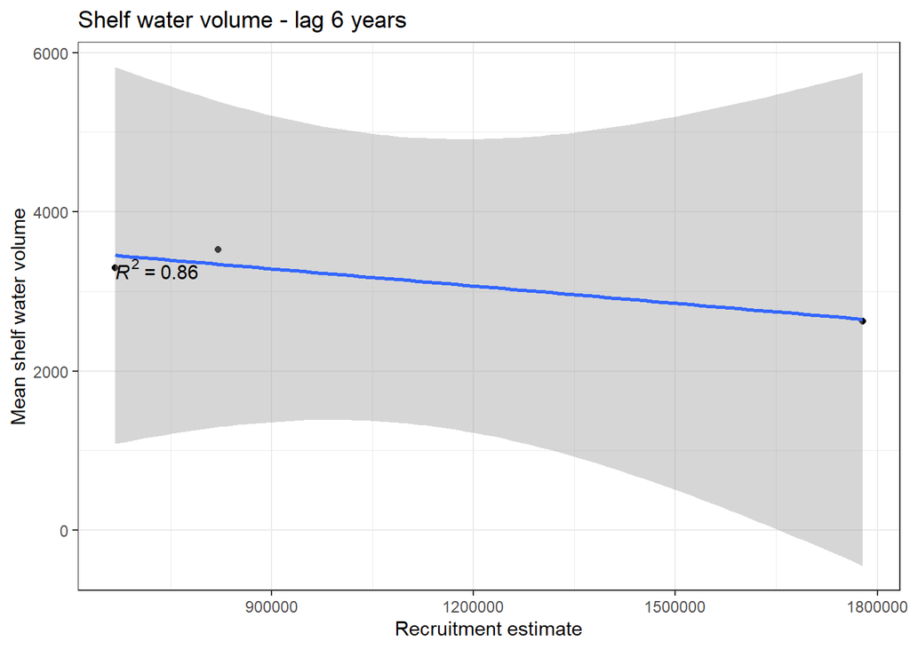

```r
## Shelf water vol 6 yr lag

ggplot2::ggplot(df.join.shlf,
                aes(x=recruit_est, y=mean_v_lag6)) +
  geom_point(color = 'black') +
  stat_smooth(method = "lm",
              formula = y ~ x,
              geom = "smooth") +
  xlab('Recruitment estimate') +
  ylab('Mean shelf water volume') +
  labs(title = 'Shelf water volume - lag 6 years') +
  stat_cor(aes(label=..rr.label..)) +
  theme_bw()
```

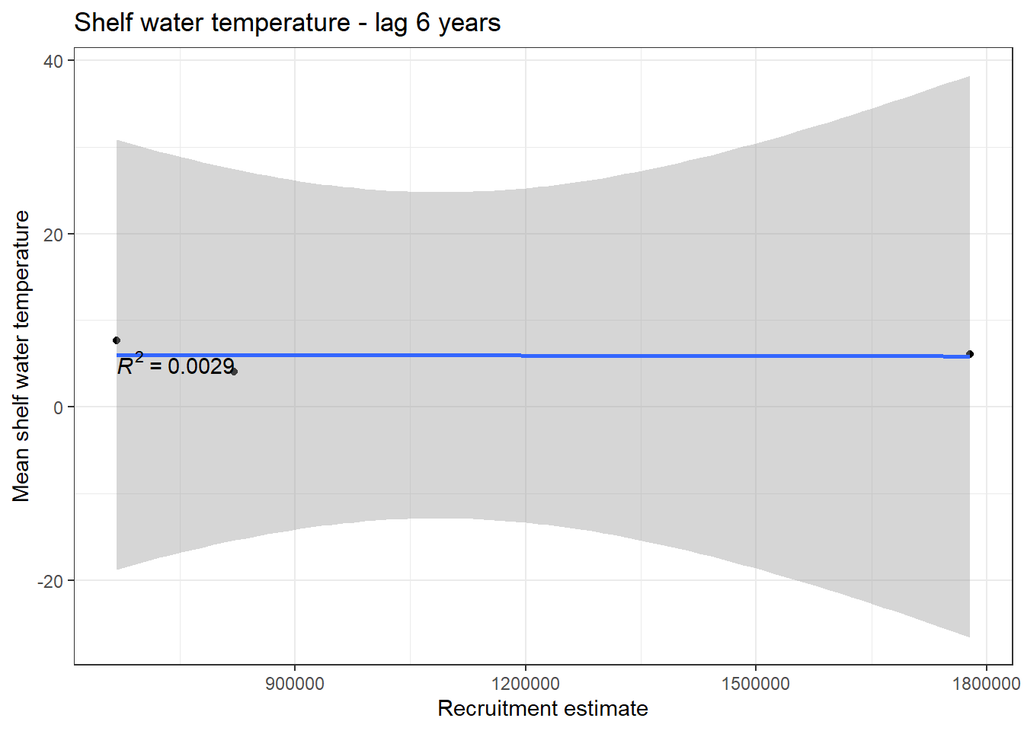

```r
## Shelf water temperature 6 yr lag
ggplot2::ggplot(df.join.shlf,
                aes(x=recruit_est, y=mean_t_lag6)) +
  geom_point(color = 'black') +
  stat_smooth(method = "lm",
              formula = y ~ x,
              geom = "smooth") +
  xlab('Recruitment estimate') +
  ylab('Mean shelf water temperature') +
  labs(title = 'Shelf water temperature - lag 6 years') +
  stat_cor(aes(label=..rr.label..)) +
  theme_bw()
```

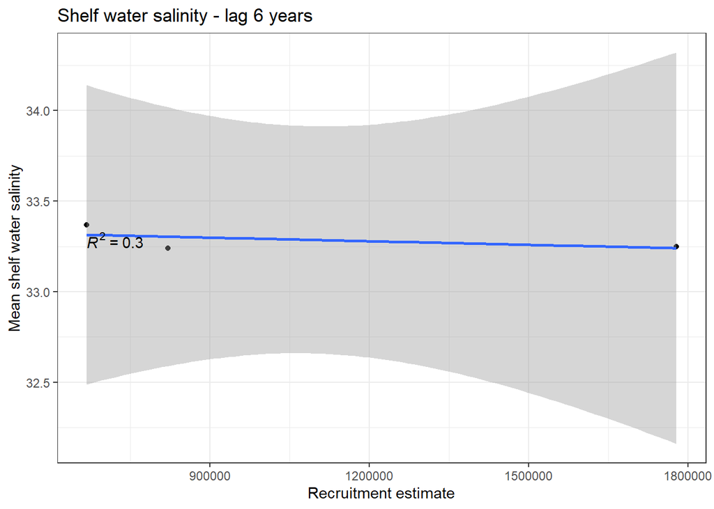

```r
## Shelf water salinity 6 yr lag
ggplot2::ggplot(df.join.shlf,
                aes(x=recruit_est, y=mean_s_lag6)) +
  geom_point(color = 'black') +
  stat_smooth(method = "lm",
              formula = y ~ x,
              geom = "smooth") +
  xlab('Recruitment estimate') +
  ylab('Mean shelf water salinity') +
  labs(title = 'Shelf water salinity - lag 6 years') +
  stat_cor(aes(label=..rr.label..)) +
  theme_bw()
```

```r
print(paste0('correlation: ', round(cor(df.join.shlf[,2], df.join.shlf[,13]), 4)))
```

```
## [1] "correlation: NA"
```

**Correlations**

```r
df.join.shlf = dplyr::full_join(recruit, df.lag, by = join_by(year)) %>%
  dplyr::select(year, month, recruit_est, mean_t, mean_s, mean_v) %>%
  tidyr::drop_na() #removing lags to visualize all months

df.join.shlf = mutate(df.join.shlf, mean_v_lag1 = lag(mean_v,12)) #creating one year lag

#by season
shlfvol_winter <- filter(df.join.shlf, month %in% c(1,2,3))
shlfvol_spring <- filter(df.join.shlf, month %in% c(4,5,6))
shlfvol_summer <- filter(df.join.shlf, month %in% c(7,8,9))
shlfvol_fall <- filter(df.join.shlf, month %in% c(10,11,12))

## shelf water volume - one year lag (summer = peak spawn)
lm_lag<-lm(mean_v_lag1 ~ recruit_est, data=shlfvol_summer)
summary(lm_lag)
```

```
##
## Call:
## lm(formula = mean_v_lag1 ~ recruit_est, data = shlfvol_summer)
##
## Residuals:
##      Min       1Q   Median       3Q      Max
## -1459.95  -542.14   -91.96   353.47  1515.80
##
## Coefficients:
##              Estimate Std. Error t value Pr(>|t|)
## (Intercept) 4.035e+03  2.214e+02  18.226   <2e-16 ***
## recruit_est 5.873e-05  1.383e-04   0.425    0.673
## ---
## Signif. codes:  0 '***' 0.001 '**' 0.01 '*' 0.05 '.' 0.1 ' ' 1
##
## Residual standard error: 745.8 on 53 degrees of freedom
##   (5 observations deleted due to missingness)
## Multiple R-squared:  0.003392,   Adjusted R-squared:  -0.01541
## F-statistic: 0.1804 on 1 and 53 DF,  p-value: 0.6727
```

```r
cor.test(shlfvol_summer$recruit_est, shlfvol_summer$mean_v_lag1, method=c("pearson"))
```

```
##
##  Pearson's product-moment correlation
##
## data:  shlfvol_summer$recruit_est and shlfvol_summer$mean_v_lag1
## t = 0.42475, df = 53, p-value = 0.6727
## alternative hypothesis: true correlation is not equal to 0
## 95 percent confidence interval:
##  -0.2103017  0.3186189
## sample estimates:
##        cor
## 0.05824508
```

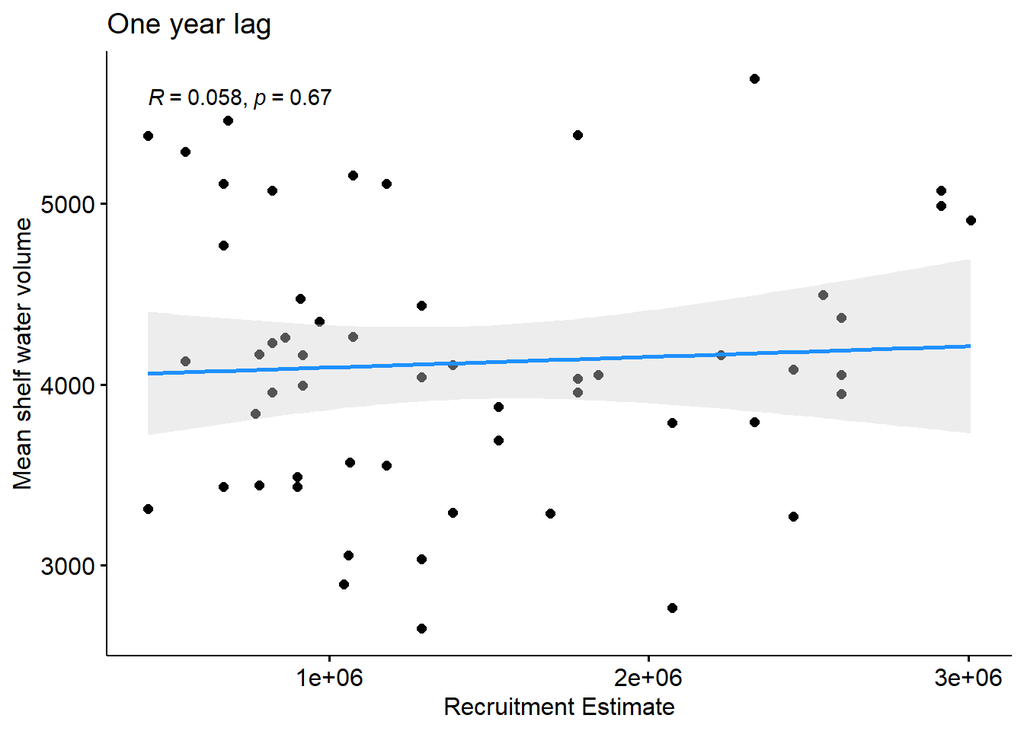

```r
ggscatter(shlfvol_summer, x = "recruit_est", y = "mean_v_lag1",
          add = "reg.line", conf.int = TRUE,
          cor.coef = TRUE, cor.coeff.args = list(method="pearson"),
          add.params=list(color="dodgerblue", fill="lightgray"),
          xlab = "Recruitment Estimate", ylab = "Mean shelf water volume",
          title="One year lag")
```

```r
## shelf water volume - winter
lm_winter<-lm(mean_v ~ recruit_est, data=shlfvol_winter)
summary(lm_winter)
```

```
##
## Call:
## lm(formula = mean_v ~ recruit_est, data = shlfvol_winter)
##
## Residuals:
##      Min       1Q   Median       3Q      Max
## -1825.94  -408.58   -48.77   589.87  1899.07
##
## Coefficients:
##              Estimate Std. Error t value Pr(>|t|)
## (Intercept) 3.562e+03  2.530e+02  14.079   <2e-16 ***
## recruit_est 8.842e-05  1.564e-04   0.565    0.574
## ---
## Signif. codes:  0 '***' 0.001 '**' 0.01 '*' 0.05 '.' 0.1 ' ' 1
##
## Residual standard error: 849.7 on 53 degrees of freedom
## Multiple R-squared:  0.005997,   Adjusted R-squared:  -0.01276
## F-statistic: 0.3198 on 1 and 53 DF,  p-value: 0.5741
```

```r
cor.test(shlfvol_winter$recruit_est, shlfvol_winter$mean_v, method=c("pearson"))
```

```
##
##  Pearson's product-moment correlation
##
## data:  shlfvol_winter$recruit_est and shlfvol_winter$mean_v
## t = 0.56548, df = 53, p-value = 0.5741
## alternative hypothesis: true correlation is not equal to 0
## 95 percent confidence interval:
##  -0.1917969  0.3358382
## sample estimates:
##        cor
## 0.07744072
```

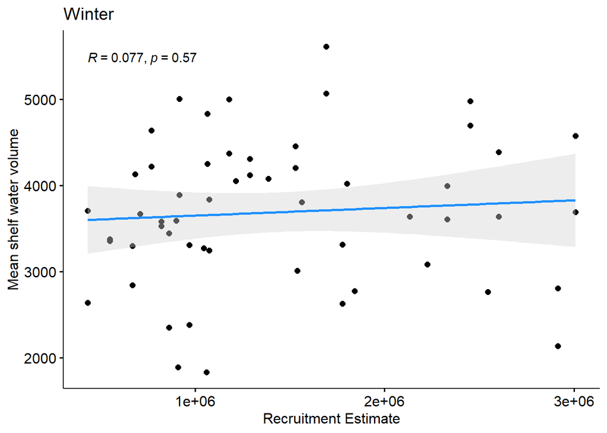

```r
ggscatter(shlfvol_winter, x = "recruit_est", y = "mean_v",
          add = "reg.line", conf.int = TRUE,
          cor.coef = TRUE, cor.coeff.args = list(method="pearson"),
          add.params=list(color="dodgerblue", fill="lightgray"),
          xlab = "Recruitment Estimate", ylab = "Mean shelf water volume",
          title="Winter")
```

```r
## shelf water volume - spring
lm_spring<-lm(mean_v ~ recruit_est, data=shlfvol_spring)
summary(lm_spring)
```

```
##
## Call:
## lm(formula = mean_v ~ recruit_est, data = shlfvol_spring)
##
## Residuals:
##     Min      1Q  Median      3Q     Max
## -1551.4  -217.0   106.6   371.5  1058.3
##
## Coefficients:
##               Estimate Std. Error t value Pr(>|t|)
## (Intercept)  4.303e+03  2.474e+02   17.39   <2e-16 ***
## recruit_est -1.105e-04  1.492e-04   -0.74    0.465
## ---
## Signif. codes:  0 '***' 0.001 '**' 0.01 '*' 0.05 '.' 0.1 ' ' 1
##
## Residual standard error: 655.8 on 29 degrees of freedom
## Multiple R-squared:  0.01856,    Adjusted R-squared:  -0.01529
## F-statistic: 0.5483 on 1 and 29 DF,  p-value: 0.465
```

```r
cor.test(shlfvol_spring$recruit_est, shlfvol_spring$mean_v, method=c("pearson"))
```

```
##
##  Pearson's product-moment correlation
##
## data:  shlfvol_spring$recruit_est and shlfvol_spring$mean_v
## t = -0.74048, df = 29, p-value = 0.465
## alternative hypothesis: true correlation is not equal to 0
## 95 percent confidence interval:
##  -0.4679736  0.2291804
## sample estimates:
##       cor
## -0.136222
```

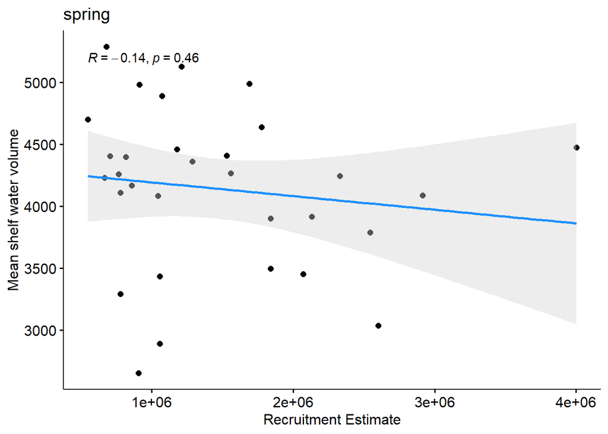

```r
ggscatter(shlfvol_spring, x = "recruit_est", y = "mean_v",
          add = "reg.line", conf.int = TRUE,
          cor.coef = TRUE, cor.coeff.args = list(method="pearson"),
          add.params=list(color="dodgerblue", fill="lightgray"),
          xlab = "Recruitment Estimate", ylab = "Mean shelf water volume",
          title="spring")
```

```r
## shelf water volume - summer
lm_summer<-lm(mean_v ~ recruit_est, data=shlfvol_summer)
summary(lm_summer)
```

```
##
## Call:
## lm(formula = mean_v ~ recruit_est, data = shlfvol_summer)
##
## Residuals:
##     Min      1Q  Median      3Q     Max
## -1826.3  -517.7  -138.3   392.3  1634.7
##
## Coefficients:
##               Estimate Std. Error t value Pr(>|t|)
## (Intercept)  4.287e+03  2.382e+02  17.995   <2e-16 ***
## recruit_est -1.007e-04  1.489e-04  -0.676    0.501
## ---
## Signif. codes:  0 '***' 0.001 '**' 0.01 '*' 0.05 '.' 0.1 ' ' 1
##
## Residual standard error: 823.4 on 58 degrees of freedom
## Multiple R-squared:  0.007827,   Adjusted R-squared:  -0.00928
## F-statistic: 0.4575 on 1 and 58 DF,  p-value: 0.5015
```

```r
cor.test(shlfvol_summer$recruit_est, shlfvol_summer$mean_v, method=c("pearson"))
```

```
##
##  Pearson's product-moment correlation
##
## data:  shlfvol_summer$recruit_est and shlfvol_summer$mean_v
## t = -0.67641, df = 58, p-value = 0.5015
## alternative hypothesis: true correlation is not equal to 0
## 95 percent confidence interval:
##  -0.3348709  0.1692581
## sample estimates:
##         cor
## -0.08846888
```

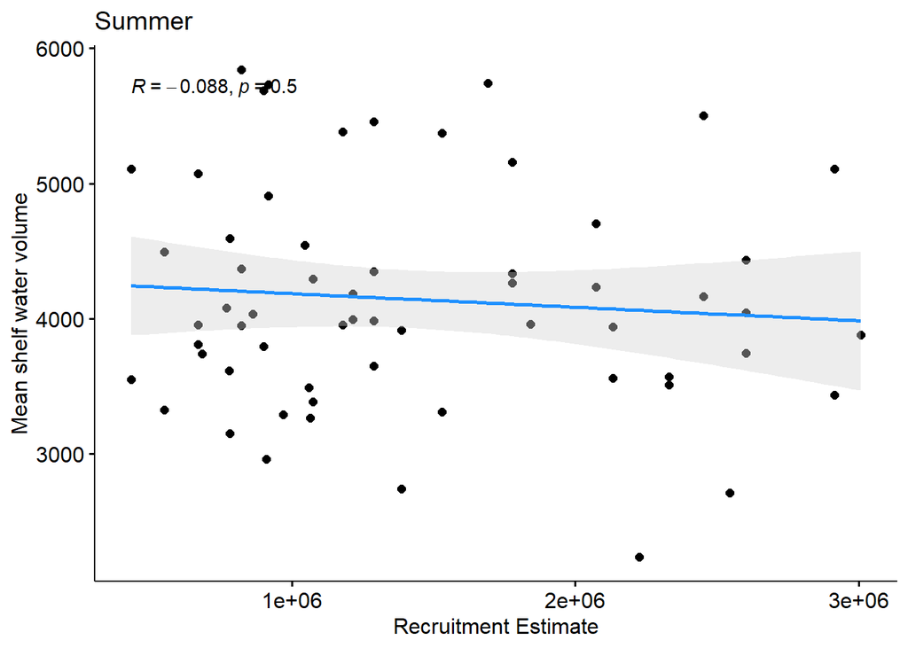

```r
ggscatter(shlfvol_summer, x = "recruit_est", y = "mean_v",
          add = "reg.line", conf.int = TRUE,
          cor.coef = TRUE, cor.coeff.args = list(method="pearson"),
          add.params=list(color="dodgerblue", fill="lightgray"),
          xlab = "Recruitment Estimate", ylab = "Mean shelf water volume",
          title="Summer")
```

```r
## shelf water volume - fall
lm_fall<-lm(mean_v ~ recruit_est, data=shlfvol_fall)
summary(lm_fall)
```

```
##
## Call:
## lm(formula = mean_v ~ recruit_est, data = shlfvol_fall)
##
## Residuals:
##     Min      1Q  Median      3Q     Max
## -1503.4  -637.8  -157.9   701.3  1399.4
##
## Coefficients:
##              Estimate Std. Error t value Pr(>|t|)
## (Intercept) 3.417e+03  3.567e+02   9.579 5.15e-10 ***
## recruit_est 4.819e-05  2.024e-04   0.238    0.814
## ---
## Signif. codes:  0 '***' 0.001 '**' 0.01 '*' 0.05 '.' 0.1 ' ' 1
##
## Residual standard error: 874.2 on 26 degrees of freedom
## Multiple R-squared:  0.002176,   Adjusted R-squared:  -0.0362
## F-statistic: 0.0567 on 1 and 26 DF,  p-value: 0.8137
```

```r
cor.test(shlfvol_fall$recruit_est, shlfvol_fall$mean_v, method=c("pearson"))
```

```
##
##  Pearson's product-moment correlation
##
## data:  shlfvol_fall$recruit_est and shlfvol_fall$mean_v
## t = 0.23811, df = 26, p-value = 0.8137
## alternative hypothesis: true correlation is not equal to 0
## 95 percent confidence interval:
##  -0.3322114  0.4125444
## sample estimates:
##      cor
## 0.046647
```

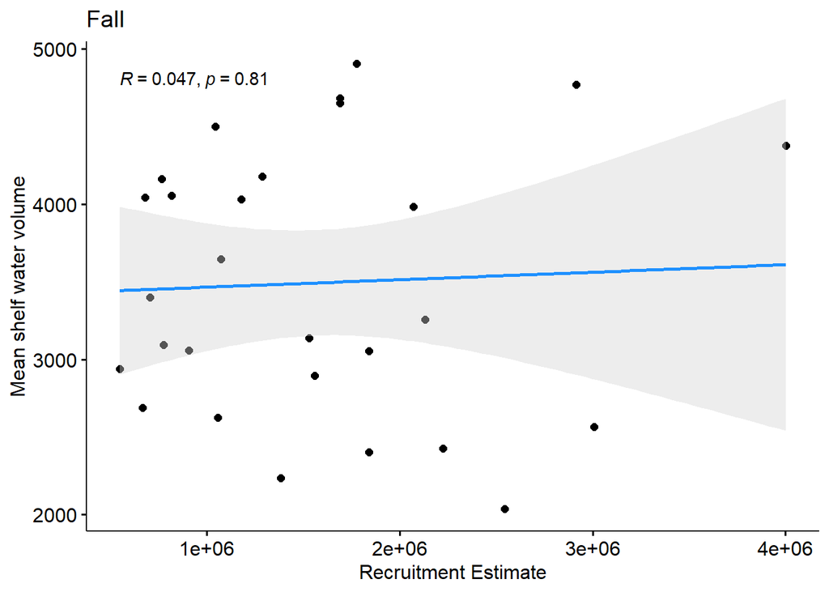

```r
ggscatter(shlfvol_fall, x = "recruit_est", y = "mean_v",
          add = "reg.line", conf.int = TRUE,
          cor.coef = TRUE, cor.coeff.args = list(method="pearson"),
          add.params=list(color="dodgerblue", fill="lightgray"),
          xlab = "Recruitment Estimate", ylab = "Mean shelf water volume",
          title="Fall")
```

```r
## shelf water temperature
lm_shlftemp<-lm(mean_t ~ recruit_est, data=df.join.shlf)
summary(lm_shlftemp)
```

```
##
## Call:
## lm(formula = mean_t ~ recruit_est, data = df.join.shlf)
##
## Residuals:
##     Min      1Q  Median      3Q     Max
## -6.8944 -4.4381  0.5717  3.8118  7.3266
##
## Coefficients:
##              Estimate Std. Error t value Pr(>|t|)
## (Intercept) 1.093e+01  7.017e-01  15.580   <2e-16 ***
## recruit_est 4.946e-08  4.271e-07   0.116    0.908
## ---
## Signif. codes:  0 '***' 0.001 '**' 0.01 '*' 0.05 '.' 0.1 ' ' 1
##
## Residual standard error: 4.237 on 172 degrees of freedom
## Multiple R-squared:  7.797e-05,  Adjusted R-squared:  -0.005736
## F-statistic: 0.01341 on 1 and 172 DF,  p-value: 0.9079
```

```r
cor.test(df.join.shlf$recruit_est, df.join.shlf$mean_t, method=c("pearson"))
```

```
##
##  Pearson's product-moment correlation
##
## data:  df.join.shlf$recruit_est and df.join.shlf$mean_t
## t = 0.11581, df = 172, p-value = 0.9079
## alternative hypothesis: true correlation is not equal to 0
## 95 percent confidence interval:
##  -0.1401238  0.1573931
## sample estimates:
##         cor
## 0.008830066
```

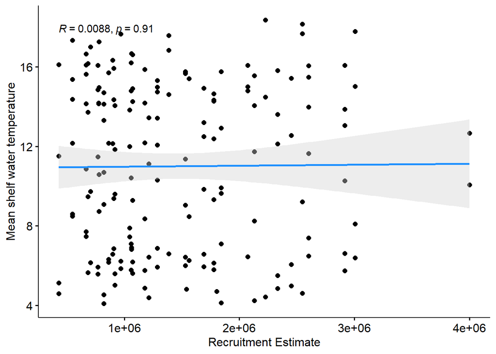

```r
ggscatter(df.join.shlf, x = "recruit_est", y = "mean_t",
          add = "reg.line", conf.int = TRUE,
          cor.coef = TRUE, cor.coeff.args = list(method="pearson"),
          add.params=list(color="dodgerblue", fill="lightgray"),
          xlab = "Recruitment Estimate", ylab = "Mean shelf water temperature")
```

```r
## shelf water salinity
lm_shlfsal<-lm(mean_s ~ recruit_est, data=df.join.shlf)
summary(lm_shlfsal)
```

```
##
## Call:
## lm(formula = mean_s ~ recruit_est, data = df.join.shlf)
##
## Residuals:
##     Min      1Q  Median      3Q     Max
## -0.9007 -0.1919  0.0226  0.2090  0.6810
##
## Coefficients:
##               Estimate Std. Error t value Pr(>|t|)
## (Intercept)  3.284e+01  5.441e-02 603.562   <2e-16 ***
## recruit_est -1.769e-08  3.311e-08  -0.534    0.594
## ---
## Signif. codes:  0 '***' 0.001 '**' 0.01 '*' 0.05 '.' 0.1 ' ' 1
##
## Residual standard error: 0.3286 on 172 degrees of freedom
## Multiple R-squared:  0.001657,   Adjusted R-squared:  -0.004147
## F-statistic: 0.2855 on 1 and 172 DF,  p-value: 0.5938
```

```r
cor.test(df.join.shlf$recruit_est, df.join.shlf$mean_s, method=c("pearson"))
```

```
##
##  Pearson's product-moment correlation
##
## data:  df.join.shlf$recruit_est and df.join.shlf$mean_s
## t = -0.53436, df = 172, p-value = 0.5938
## alternative hypothesis: true correlation is not equal to 0
## 95 percent confidence interval:
##  -0.1883400  0.1087174
## sample estimates:
##         cor
## -0.04071088
```

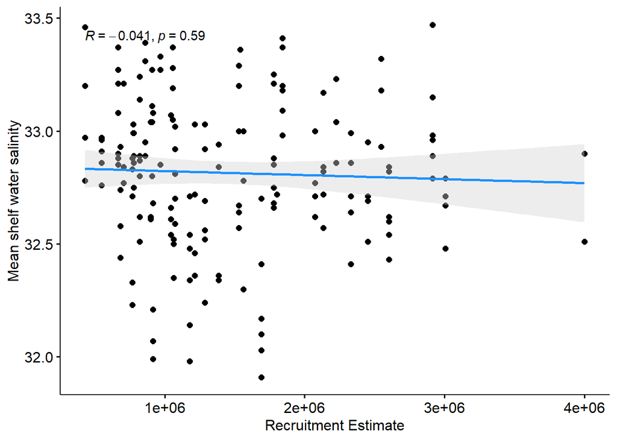

```r
ggscatter(df.join.shlf, x = "recruit_est", y = "mean_s",
          add = "reg.line", conf.int = TRUE,
          cor.coef = TRUE, cor.coeff.args = list(method="pearson"),
          add.params=list(color="dodgerblue", fill="lightgray"),
          xlab = "Recruitment Estimate", ylab = "Mean shelf water salinity")
```

##### Gulf-stream index

Gulf stream index was calculated based on method presented by Pérez-Hernández and Joyce (2014). The gulf stream index (GSI) is a measure of the degrees latitude above the average Gulf Stream position based on ocean temperature at 200m (15 C) depth between 55W to 75W.

Positive values indicate a the mean position of the GS is more Northernly, whereas negative values indicate a more Southernly position.

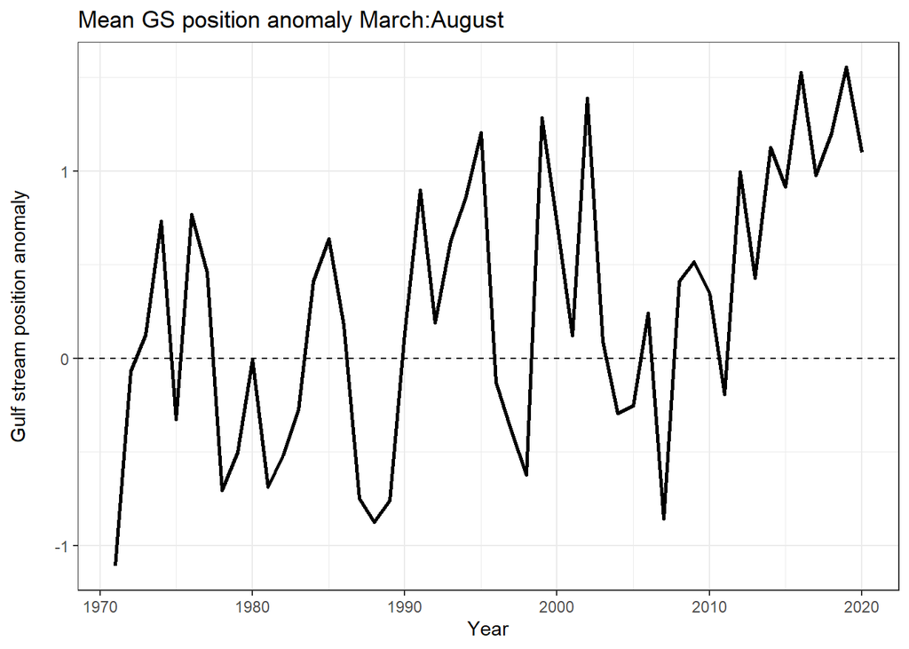

```r
# positive are more Northerly, negative are more southernly

## --- Note below is the original data source, which was modified to include
## --- month and then saved as a new file (mm_gsi_1954_2022_chen.csv).
# gsi.a <- ecodata::gsi
# gsi.m <- read.csv(here::here('data/gulf_stream_index/Chen_EN4_T200_GSI_1954_2022_monthly - Zhuomin Chen.xlsx - Sheet1.csv'))

# # weird inefficient solution I came up with to get month values (but it works)
# gsi.m$year <- as.numeric(gsub("(^\\d{4}).*", "\\1", gsi.m$Month))
# gsi.m$m.1 <- round(str_extract(gsi.m$Month, '\\d+([.,]\\d+)?') %>% as.numeric()- gsi.m$year,2)
# gsi.m$month <- round(as.numeric(str_extract(gsi.m$m.1, '\\d\\d')))
# is.na(gsi.m$month) <- 10
# gsi.m$month <- replace(gsi.m$month, is.na(gsi.m$month), 10)
# gsi.m <- gsi.m[,-4]
# # saving so don't have to do that everytime:
# write.csv(gsi.m, 'mm_gsi_1954_2022_chen.csv') #


gsi.m <- read.csv(here::here('data/gulf_stream_index/mm_gsi_1954_2022_chen.csv'))

# df <- dplyr::full_join(recruit, gsi.m, by = join_by(year)) %>%
#   dplyr::select(year, month, recruit_est, GSI) %>%
#   filter(month %in% c(3:9)) %>%
#   tidyr::pivot_wider(names_from = c(month),
#                      values_from = c(GSI)) %>%
#   rlang::set_names(c('year','recruit_est','Mar', 'Apr', 'May',                                                                   'Jun', 'Jul', 'Aug', 'Sep')) %>%
#   tidyr::drop_na()


## --- This joins recruit estimate data to GSI data and
## --- calculates some summary stats(mean, sd, min, max)
df <- dplyr::full_join(recruit, gsi.m %>%
                   group_by(year) %>%
                   filter(month %in% c(3:8)) %>%
                   summarise(m.gsi = mean(GSI),
                             sd.gsi = sd(GSI),
                             max.gsi = max(GSI),
                             min.gsi = min(GSI)),
                 by = join_by(year)) %>%
  mutate(pos = ifelse(m.gsi > 0, 'Northerly', 'Southerly'),
         n.pos = ifelse(m.gsi > 0, 1, 0))
df <- df[-c(51:69),] # this removes rows w/years that don't match
# (could/should do this before hand in more standardized way - will do later)

# Plot the time series (mean GSI for the months of interest)
# -- Note: here I am looking just at March through August assuming these
# months are the most important to recently spawned individuals
ggplot(data = df,
       aes(x = year, y = m.gsi)) +
  geom_line(lwd = 1) +
  geom_hline(yintercept = 0, lty = 2) +
  labs(title = 'Mean GS position anomaly March:August',
       x = 'Year',
       y = "Gulf stream position anomaly\n") +
theme_bw()
```

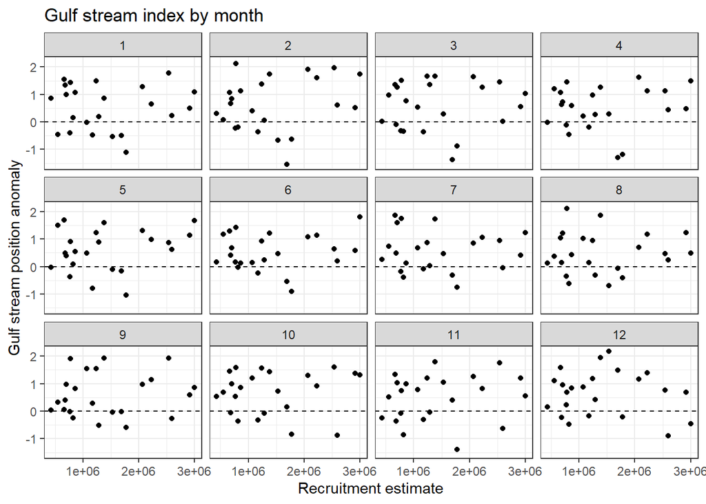

```r
# dplyr::full_join(recruit, gsi.m, by = join_by(year)) %>%
#   dplyr::select(year, month, recruit_est, GSI) %>%
#   #filter(month %in% c(3:9)) %>%
#   filter(year>1997) %>%
#   tidyr::drop_na() %>%
#   ggplot2::ggplot(.,aes(x=recruit_est, y=GSI)) +
#   geom_point(color = 'black') +
#   xlab('Recruitment estimate') +
#   ylab('Gulf stream position anomaly') +
#   labs(title = 'Gulf stream index') +
#   geom_hline(yintercept = 0, lty = 2) +
#   theme_bw()


# Looking across all months
dplyr::full_join(recruit, gsi.m, by = join_by(year)) %>%
  dplyr::select(year, month, recruit_est, GSI) %>%
  #filter(month %in% c(3:9)) %>%
  filter(year>1997) %>%
  tidyr::drop_na() %>%
ggplot2::ggplot(.,aes(x=recruit_est, y=GSI)) +
  geom_point(color = 'black') +
  facet_wrap(~month)+
  xlab('Recruitment estimate') +
  ylab('Gulf stream position anomaly') +
  labs(title = 'Gulf stream index by month') +
  geom_hline(yintercept = 0, lty = 2) +
  theme_bw()
```

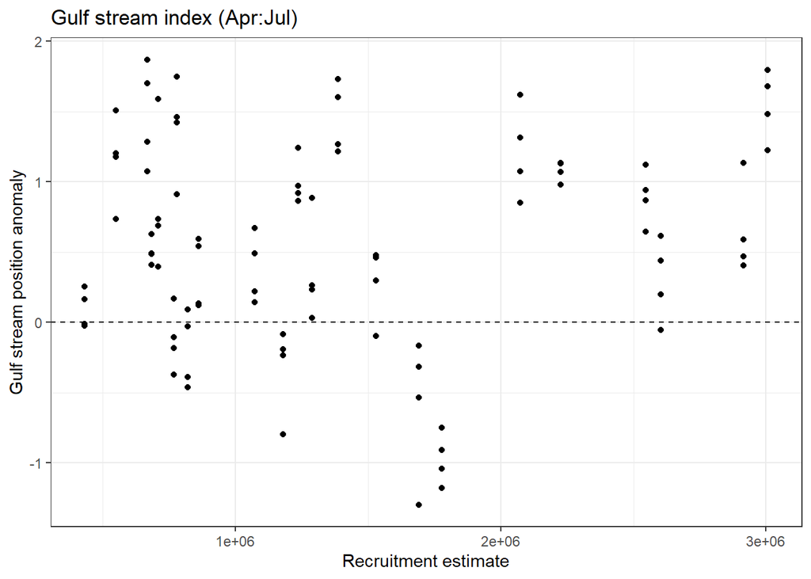

```r
# Looking across April through July
dplyr::full_join(recruit, gsi.m, by = join_by(year)) %>%
  dplyr::select(year, month, recruit_est, GSI) %>%
  #filter(month %in% c(3:9)) %>%
  filter(year>1997 & month %in% c(4:7)) %>%
  tidyr::drop_na() %>%
  ggplot2::ggplot(.,aes(x=recruit_est, y=GSI)) +
  geom_point(color = 'black') +
  xlab('Recruitment estimate') +
  ylab('Gulf stream position anomaly') +
  labs(title = 'Gulf stream index (Apr:Jul)') +
  geom_hline(yintercept = 0, lty = 2) +
  theme_bw()
```

**Correlations**

```r
df.gsi = dplyr::full_join(recruit, gsi.m, by = join_by(year)) %>%
  dplyr::select(year, month, recruit_est, GSI) %>%
  mutate(gsi_lag1 = lag(GSI,12)) %>%
  filter(year>1997) %>%
  tidyr::drop_na() #GSI by month and with year lag

#by season
gsi_winter <- filter(df.gsi, month %in% c(1,2,3))
gsi_spring <- filter(df.gsi, month %in% c(4,5,6))
gsi_summer <- filter(df.gsi, month %in% c(7,8,9))
gsi_fall <- filter(df.gsi, month %in% c(10,11,12))

## GSI - one year lag
lm_lag<-lm(gsi_lag1 ~ recruit_est, data=gsi_summer)
summary(lm_lag)
```

```
##
## Call:
## lm(formula = gsi_lag1 ~ recruit_est, data = gsi_summer)
##
## Residuals:
##      Min       1Q   Median       3Q      Max
## -1.25835 -0.53882 -0.09034  0.50124  1.57858
##
## Coefficients:
##               Estimate Std. Error t value Pr(>|t|)
## (Intercept)  5.700e-01  1.918e-01   2.972   0.0041 **
## recruit_est -4.877e-08  1.182e-07  -0.413   0.6812
## ---
## Signif. codes:  0 '***' 0.001 '**' 0.01 '*' 0.05 '.' 0.1 ' ' 1
##
## Residual standard error: 0.7602 on 67 degrees of freedom
## Multiple R-squared:  0.002536,   Adjusted R-squared:  -0.01235
## F-statistic: 0.1703 on 1 and 67 DF,  p-value: 0.6812
```

```r
cor.test(gsi_summer$recruit_est, gsi_summer$gsi_lag1, method=c("pearson"))
```

```
##
##  Pearson's product-moment correlation
##
## data:  gsi_summer$recruit_est and gsi_summer$gsi_lag1
## t = -0.41269, df = 67, p-value = 0.6812
## alternative hypothesis: true correlation is not equal to 0
## 95 percent confidence interval:
##  -0.2836542  0.1885740
## sample estimates:
##         cor
## -0.05035404
```

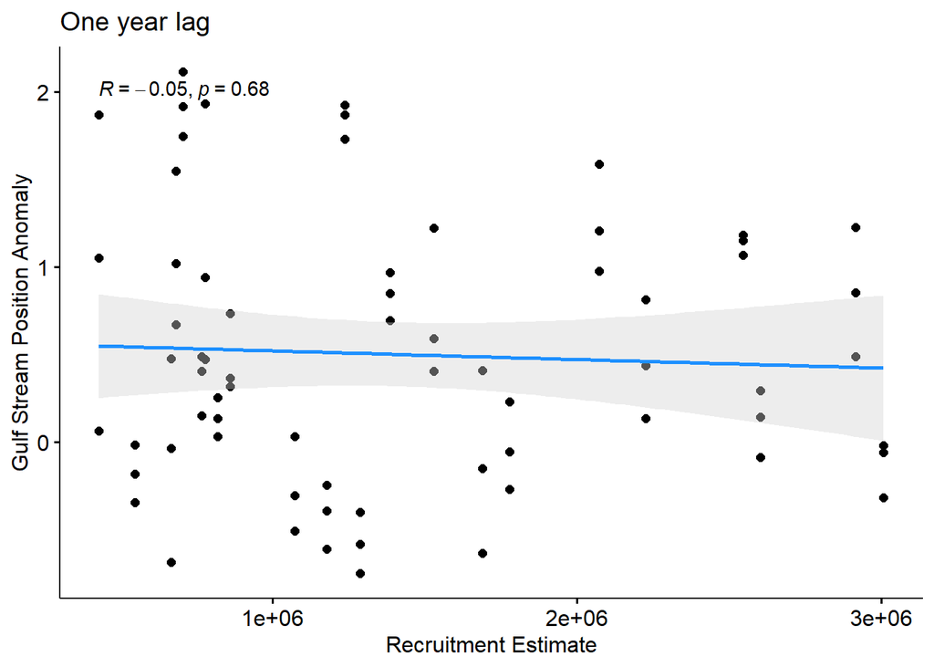

```r
ggscatter(gsi_summer, x = "recruit_est", y = "gsi_lag1",
          add = "reg.line", conf.int = TRUE,
          cor.coef = TRUE, cor.coeff.args = list(method="pearson"),
          add.params=list(color="dodgerblue", fill="lightgray"),
          xlab = "Recruitment Estimate", ylab = "Gulf Stream Position Anomaly",
          title="One year lag")
```

```r
## GSI - winter
lm_winter<-lm(GSI ~ recruit_est, data=gsi_winter)
summary(lm_winter)
```

```
##
## Call:
## lm(formula = GSI ~ recruit_est, data = gsi_winter)
##
## Residuals:
##      Min       1Q   Median       3Q      Max
## -2.16418 -0.68857  0.00435  0.78957  1.61442
##
## Coefficients:
##              Estimate Std. Error t value Pr(>|t|)
## (Intercept) 3.965e-01  2.241e-01   1.769   0.0814 .
## recruit_est 1.343e-07  1.381e-07   0.972   0.3345
## ---
## Signif. codes:  0 '***' 0.001 '**' 0.01 '*' 0.05 '.' 0.1 ' ' 1
##
## Residual standard error: 0.8886 on 67 degrees of freedom
## Multiple R-squared:  0.01391,    Adjusted R-squared:  -0.0008119
## F-statistic: 0.9448 on 1 and 67 DF,  p-value: 0.3345
```

```r
cor.test(gsi_winter$recruit_est, gsi_winter$GSI, method=c("pearson"))
```

```
##
##  Pearson's product-moment correlation
##
## data:  gsi_winter$recruit_est and gsi_winter$GSI
## t = 0.97203, df = 67, p-value = 0.3345
## alternative hypothesis: true correlation is not equal to 0
## 95 percent confidence interval:
##  -0.1221670  0.3449758
## sample estimates:
##       cor
## 0.1179234
```

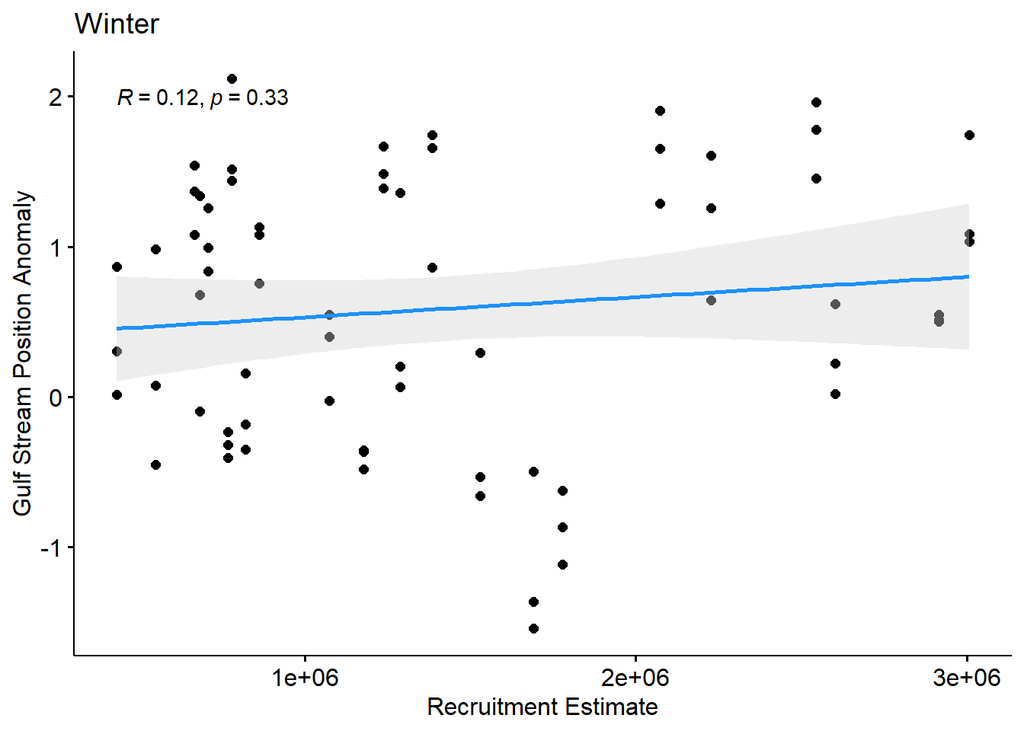

```r
ggscatter(gsi_winter, x = "recruit_est", y = "GSI",
          add = "reg.line", conf.int = TRUE,
          cor.coef = TRUE, cor.coeff.args = list(method="pearson"),
          add.params=list(color="dodgerblue", fill="lightgray"),
          xlab = "Recruitment Estimate", ylab = "Gulf Stream Position Anomaly",
          title="Winter")
```

```r
## GSI - spring
lm_spring<-lm(GSI ~ recruit_est, data=gsi_spring)
summary(lm_spring)
```

```
##
## Call:
## lm(formula = GSI ~ recruit_est, data = gsi_spring)
##
## Residuals:
##     Min      1Q  Median      3Q     Max
## -1.8868 -0.3629 -0.0042  0.4637  1.2688
##
## Coefficients:
##              Estimate Std. Error t value Pr(>|t|)
## (Intercept) 3.253e-01  1.845e-01   1.764   0.0824 .
## recruit_est 1.557e-07  1.137e-07   1.370   0.1754
## ---
## Signif. codes:  0 '***' 0.001 '**' 0.01 '*' 0.05 '.' 0.1 ' ' 1
##
## Residual standard error: 0.7313 on 67 degrees of freedom
## Multiple R-squared:  0.02723,    Adjusted R-squared:  0.01271
## F-statistic: 1.876 on 1 and 67 DF,  p-value: 0.1754
```

```r
cor.test(gsi_spring$recruit_est, gsi_spring$GSI, method=c("pearson"))
```

```
##
##  Pearson's product-moment correlation
##
## data:  gsi_spring$recruit_est and gsi_spring$GSI
## t = 1.3695, df = 67, p-value = 0.1754
## alternative hypothesis: true correlation is not equal to 0
## 95 percent confidence interval:
##  -0.07457117  0.38660302
## sample estimates:
##       cor
## 0.1650221
```

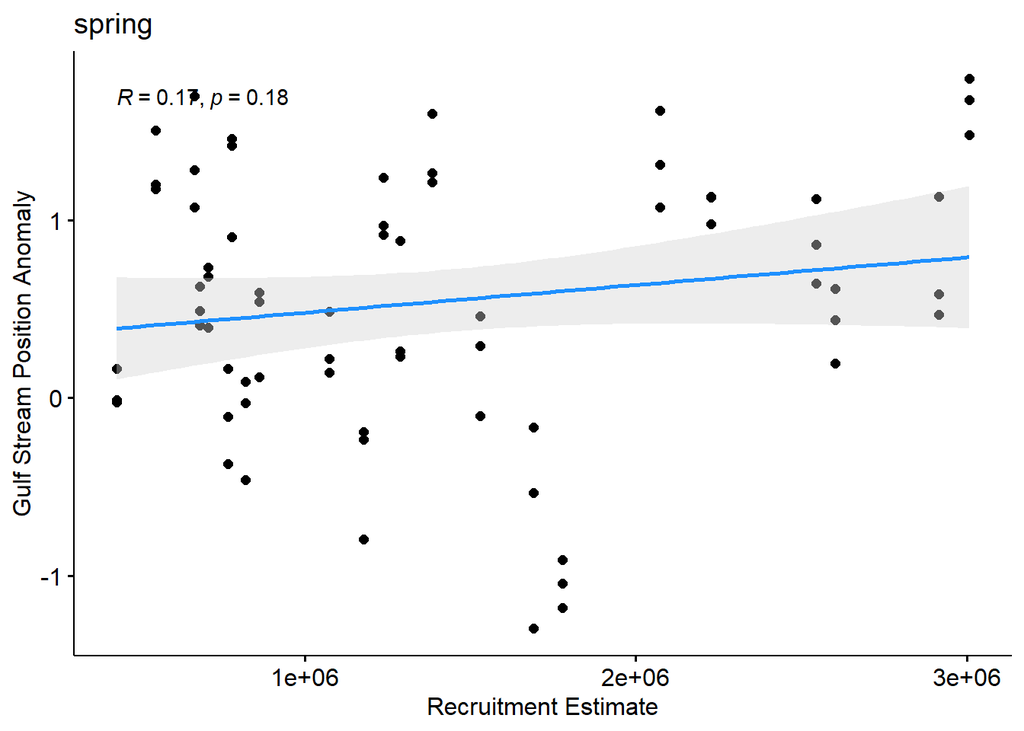

```r
ggscatter(gsi_spring, x = "recruit_est", y = "GSI",
          add = "reg.line", conf.int = TRUE,
          cor.coef = TRUE, cor.coeff.args = list(method="pearson"),
          add.params=list(color="dodgerblue", fill="lightgray"),
          xlab = "Recruitment Estimate", ylab = "Gulf Stream Position Anomaly",
          title="spring")
```

```r
## GSI - summer
lm_summer<-lm(GSI ~ recruit_est, data=gsi_summer)
summary(lm_summer)
```

```
##
## Call:
## lm(formula = GSI ~ recruit_est, data = gsi_summer)
##
## Residuals:
##     Min      1Q  Median      3Q     Max
## -1.3212 -0.5852 -0.1173  0.4797  1.5880
##
## Coefficients:
##              Estimate Std. Error t value Pr(>|t|)
## (Intercept) 4.918e-01  1.906e-01   2.581   0.0121 *
## recruit_est 4.398e-08  1.174e-07   0.374   0.7092
## ---
## Signif. codes:  0 '***' 0.001 '**' 0.01 '*' 0.05 '.' 0.1 ' ' 1
##
## Residual standard error: 0.7556 on 67 degrees of freedom
## Multiple R-squared:  0.002089,   Adjusted R-squared:  -0.01281
## F-statistic: 0.1402 on 1 and 67 DF,  p-value: 0.7092
```

```r
cor.test(gsi_summer$recruit_est, gsi_summer$GSI, method=c("pearson"))
```

```
##
##  Pearson's product-moment correlation
##
## data:  gsi_summer$recruit_est and gsi_summer$GSI
## t = 0.37448, df = 67, p-value = 0.7092
## alternative hypothesis: true correlation is not equal to 0
## 95 percent confidence interval:
##  -0.1930668  0.2793612
## sample estimates:
##        cor
## 0.04570227
```

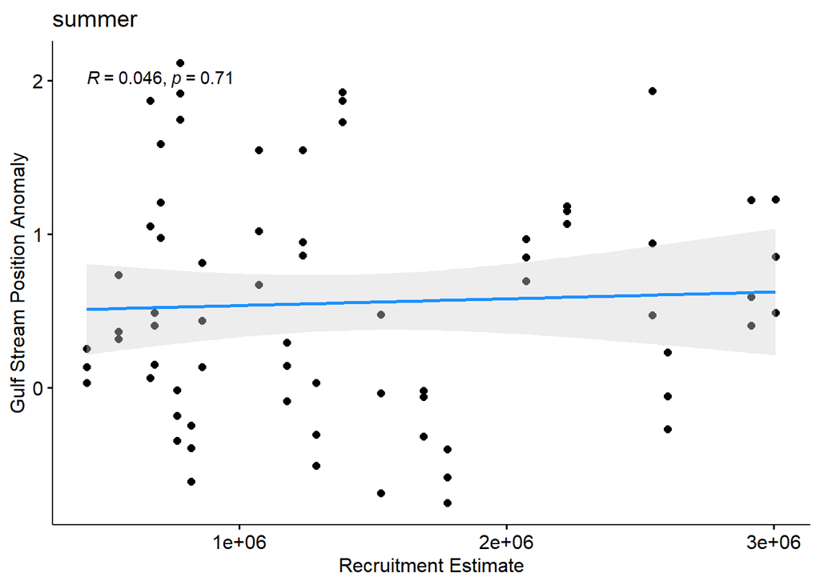

```r
ggscatter(gsi_summer, x = "recruit_est", y = "GSI",
          add = "reg.line", conf.int = TRUE,
          cor.coef = TRUE, cor.coeff.args = list(method="pearson"),
          add.params=list(color="dodgerblue", fill="lightgray"),
          xlab = "Recruitment Estimate", ylab = "Gulf Stream Position Anomaly",
          title="summer")
```

```r
## GSI - fall
lm_fall<-lm(GSI ~ recruit_est, data=gsi_fall)
summary(lm_fall)
```

```
##
## Call:
## lm(formula = GSI ~ recruit_est, data = gsi_fall)
##
## Residuals:
##     Min      1Q  Median      3Q     Max
## -2.0182 -0.6567  0.1503  0.5979  1.5617
##
## Coefficients:
##              Estimate Std. Error t value Pr(>|t|)
## (Intercept) 5.572e-01  2.055e-01   2.712  0.00849 **
## recruit_est 4.091e-08  1.266e-07   0.323  0.74762
## ---
## Signif. codes:  0 '***' 0.001 '**' 0.01 '*' 0.05 '.' 0.1 ' ' 1
##
## Residual standard error: 0.8146 on 67 degrees of freedom
## Multiple R-squared:  0.001556,   Adjusted R-squared:  -0.01335
## F-statistic: 0.1044 on 1 and 67 DF,  p-value: 0.7476
```

```r
cor.test(gsi_fall$recruit_est, gsi_fall$GSI, method=c("pearson"))
```

```
##
##  Pearson's product-moment correlation
##
## data:  gsi_fall$recruit_est and gsi_fall$GSI
## t = 0.3231, df = 67, p-value = 0.7476
## alternative hypothesis: true correlation is not equal to 0
## 95 percent confidence interval:
##  -0.1990968  0.2735694
## sample estimates:
##        cor
## 0.03944253
```

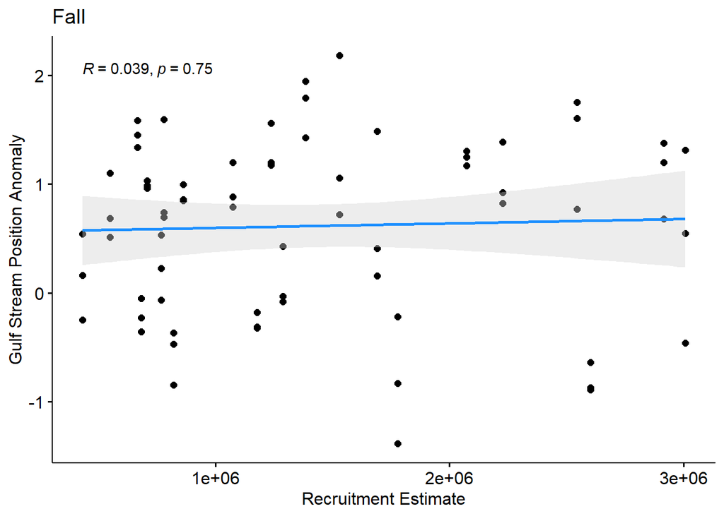

```r
ggscatter(gsi_fall, x = "recruit_est", y = "GSI",
          add = "reg.line", conf.int = TRUE,
          cor.coef = TRUE, cor.coeff.args = list(method="pearson"),
          add.params=list(color="dodgerblue", fill="lightgray"),
          xlab = "Recruitment Estimate", ylab = "Gulf Stream Position Anomaly",
          title="Fall")
```

Should I add a lag? If so, how much? From Nesslage_ea_21: For the Northern stock- From the original 49 explanatory variables, the final RF model included 10 variables: annual AMO (lagged 5–7 years); December to April AMO (lagged 5–7 years); station-based December to February NAO (lagged 3 and 4 years); PC-based December to February NAO (lagged 4 years), and management time block (Table 1; Figure S3). The final GAMM based on backward selection of variables in- cluded December to April AMO lagged 7 years and station-based December to February NAO lagged 3 and 4 years (Table 1). The shapes of the relationships approximated by the RF and GAMM indi- cate that golden tilefish landings were higher during negative AMO and positive NAO, with their respective lags (Figures 2 and 3). The largest range of the smoothed term on the y-axis corresponded with December to April AMO lagged 7 years (Figures 2 and 3) and this co- variate contributed 52.5% of the GAM R2 (Figure 4), implying AMO has the largest influence on northern landings. In contrast, NAO co-variates at lags of 3 and 4 years contributed a combined 47.5% of the GAM R2 (Figure 4).

The random forest using the full dataset identified 62 significant variables from the original 121 explanatory variables (Table 1), including two versions of the AMO (annual and seasonal with each lagged 0–7 years), both seasonal versions of PC-based NAO (each lagged 0–7 years), Labrador Current transport indices (NE Track 191: lagged 0, 4, 9, and 10 quarters), Gulf Stream index of position anomalies (lagged 0, 1, 4–10, and 12 quarters), Gulf stream position indices (lagged 0–3 years), Gulf stream transport index (lagged 0–3 years), bottom temperature anomalies (lagged 0–2, 4–7 years), and time block (Figure S1). The final GAMM for northern CPUE in- cluded four variables: annual AMO lagged 6 years, December to April AMO lagged 7 years, Gulf Stream index of position anomalies lagged 12 quarters, and the Labrador Current transport index for NE Track 191 unlagged (Table 1; Figure 5). Annual AMO lagged 6 years and December to April AMO lagged 7 years contributed a combined 64.1% of the GAM R2(Figure 4). Gulf Stream and Labrador Current transport indices contributed only 19.7% and 16.2%, respectively, of the GAM R2(Figure 4).

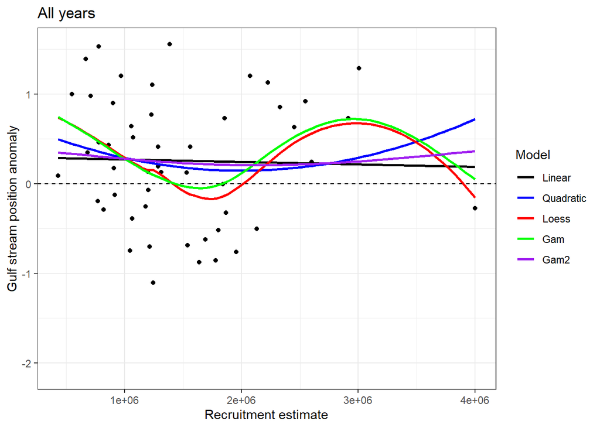

```r
# recruitment index across all years
dplyr::full_join(recruit, gsi.m %>%
                     group_by(year) %>%
                     filter(month %in% c(3:8)) %>%
                     summarise(m.gsi = mean(GSI)),
                   by = join_by(year)) %>%
  ggplot2::ggplot(., aes(x=recruit_est, y=m.gsi)) +
  geom_point(color = 'black') +
  geom_hline(yintercept = 0, lty = 2)+
  labs(title = 'All years') +
  xlab('Recruitment estimate') +
  ylab('Gulf stream position anomaly') +
  geom_smooth(method = "lm", formula = y ~ x, size = 1, se = FALSE,
              aes(colour = 'Linear')) +
  geom_smooth(method = "lm", formula = y ~ x + I(x^2),
              size = 1, se = FALSE, aes(colour = 'Quadratic')) +
  geom_smooth(method = "loess", formula = y ~ x,
              size = 1, se = FALSE, aes(colour = 'Loess')) +
  geom_smooth(method = "gam", formula = y ~  s(x),
              size = 1, se = FALSE, aes(colour = 'Gam')) +
  geom_smooth(method = "gam", formula = y ~ s(x, k = 3),
              size = 1, se = FALSE, aes(colour = 'Gam2')) +
  scale_color_manual(name='Model',
                     breaks=c('Linear', 'Quadratic', 'Loess', 'Gam', 'Gam2'),
                     values=c('Linear'='black', 'Quadratic'='blue',
                              'Loess'='red', 'Gam' = 'green',
                              'Gam2' = 'purple')) +
  theme_bw()
```

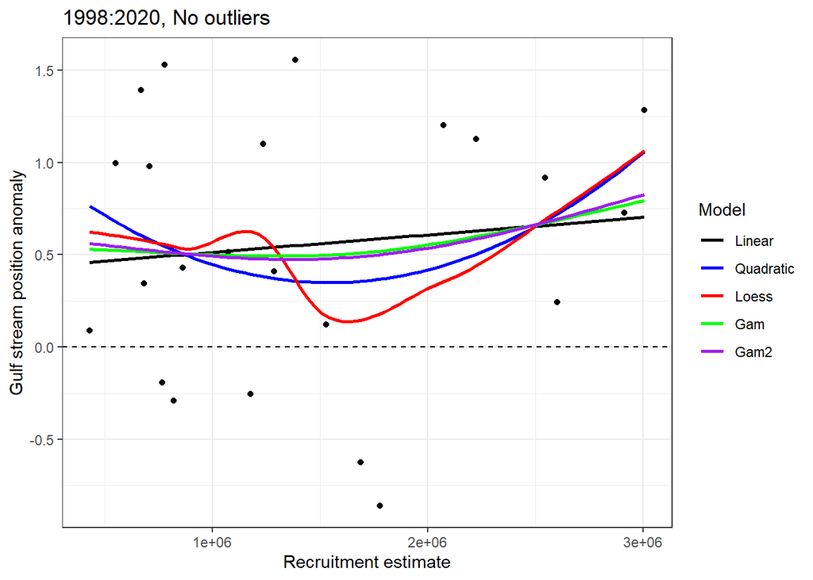

```r
# recruitment index across just the years that Paul recommended + el nino 1998

tt = dplyr::full_join(recruit, gsi.m %>%
                     group_by(year) %>%
                     filter(month %in% c(3:8)) %>%
                     summarise(m.gsi = mean(GSI)),
                   by = join_by(year))
  ggplot2::ggplot(tt %>% filter(year>1997), aes(x=recruit_est, y=m.gsi)) +
  geom_point(color = 'black') +
  geom_hline(yintercept = 0, lty = 2)+
  labs(title = '1998:2020, No outliers') +
  xlab('Recruitment estimate') +
  ylab('Gulf stream position anomaly') +
  geom_smooth(method = "lm", formula = y ~ x, size = 1, se = FALSE,
              aes(colour = 'Linear')) +
  geom_smooth(method = "lm", formula = y ~ x + I(x^2),
              size = 1, se = FALSE, aes(colour = 'Quadratic')) +
  geom_smooth(method = "loess", formula = y ~ x,
              size = 1, se = FALSE, aes(colour = 'Loess')) +
  geom_smooth(method = "gam", formula = y ~  s(x),
              size = 1, se = FALSE, aes(colour = 'Gam')) +
  geom_smooth(method = "gam", formula = y ~ s(x, k = 3),
              size = 1, se = FALSE, aes(colour = 'Gam2')) +
  scale_color_manual(name='Model',
                     breaks=c('Linear', 'Quadratic', 'Loess', 'Gam', 'Gam2'),
                     values=c('Linear'='black', 'Quadratic'='blue',
                              'Loess'='red', 'Gam' = 'green',
                              'Gam2' = 'purple')) +
  theme_bw()
```

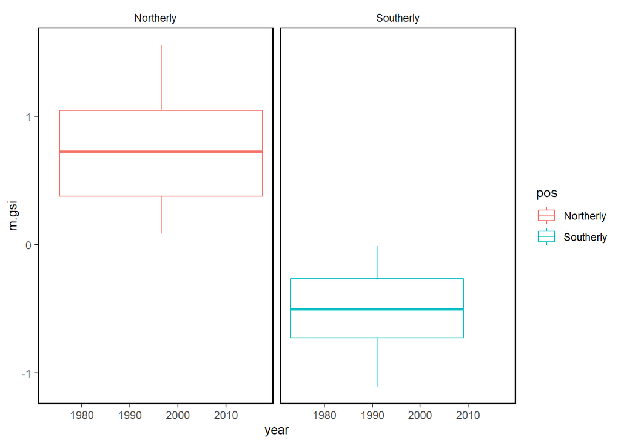

```r
ggplot(data = df, # add the data
       aes(x = year, y = m.gsi, # set x, y coordinates
           color = pos)) +    # color by GS position
  geom_boxplot() +
  facet_grid(~pos) + # create panes base on GS position
  ecodata::theme_facet()
```

```r
# this gives main effects AND interactions
pos_aov <- aov(recruit_est ~ year * pos,
              data = df)

# look at effects and interactions
# summary(pos_aov)
tidy_pos_aov <- broom::tidy(pos_aov)
tidy_pos_aov
```

```
## # A tibble: 4 × 6
##   term         df   sumsq        meansq statistic p.value
##   <chr>     <dbl>   <dbl>         <dbl>     <dbl>   <dbl>
## 1 year          1 3.85e11 384693730334.     0.717   0.401
## 2 pos           1 5.37e10  53734167452.     0.100   0.753
## 3 year:pos      1 6.82e11 682304704182.     1.27    0.265
## 4 Residuals    46 2.47e13 536176435236.    NA      NA
```

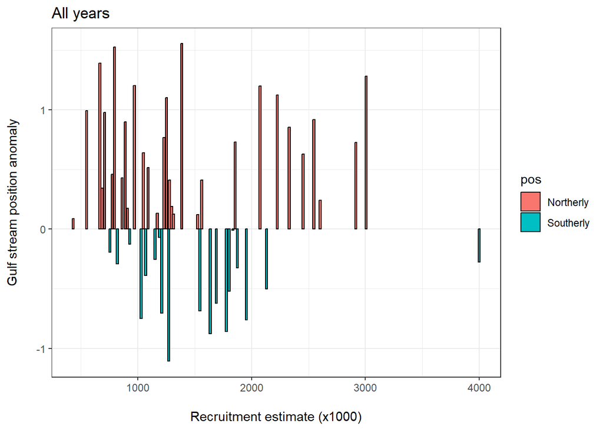

```r
# write.csv(tidy_pos_aov, 'gs_pos_aov.csv')



ggplot(data = df,
             aes(x = recruit_est/1000, y = m.gsi, fill = pos,
                 group = year)) +
   geom_bar(color = "black", stat = "identity",
            position = position_dodge2(preserve = "single"), width = 20) +
  theme_bw() +
  labs(title = 'All years',
       x = "\nRecruitment estimate (x1000)",
       y = "Gulf stream position anomaly\n")
```

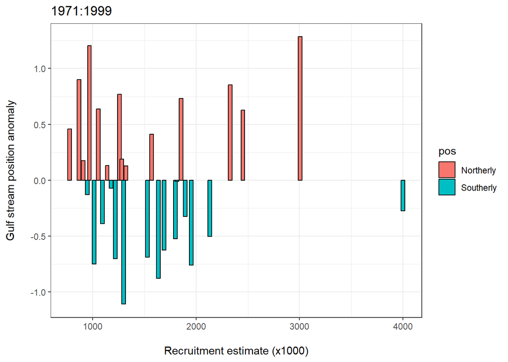

```r
ggplot(data = df %>% filter(year <= 1999),
       aes(x = recruit_est/1000, y = m.gsi, fill = pos,
           group = year)) +
  geom_bar(color = "black", stat = "identity",
           position = position_dodge2(preserve = "single"), width = 40) +
  theme_bw() +
  labs(title = '1971:1999',
       x = "\nRecruitment estimate (x1000)",
       y = "Gulf stream position anomaly\n")
```

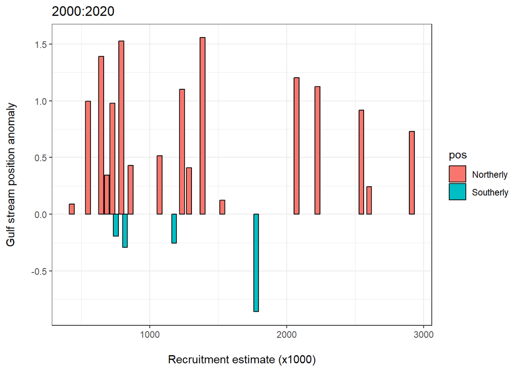

```r
ggplot(data = df %>% filter(year >1999),
       aes(x = recruit_est/1000, y = m.gsi, fill = pos,
           group = year)) +
  geom_bar(color = "black", stat = "identity",
           position = position_dodge2(preserve = "single"), width = 40) +
  theme_bw() +
  labs(title = '2000:2020',
       x = "\nRecruitment estimate (x1000)",
       y = "Gulf stream position anomaly\n")
```

#### Food availablity

Larval tilefish eat zooplankton, likely calanus. *Calanus finmarchicus* are a copepod (crustacean) with a one-year life cycle and are an important food source for many commercially important species. Calanus spp. are lipid rich, herbivorous species that eat phytoplankton, diatoms in particular (Hobbs et al. 2020).

Diatoms are often represented as microplankton (>20 µm), but many species are of the nanoplankton size class (2-20 µm), and a smaller few may even overlap with picoplanton size class (<2 µm).

##### Calanus

Calanus is not as common in MAB, need to figure out dominant zooplankton in MAB.

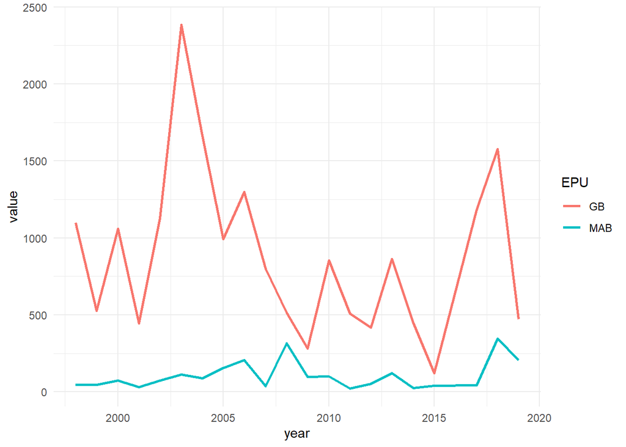

```r
# Calanus
calanus <- ecodata::calanus_stage %>% filter(Time %in% c(1998:2021))%>%
    rename_all(., .funs = tolower) %>%
   mutate(year = time)


ggplot() +
  geom_line(data = calanus %>% filter(epu == 'GB',
                                  var == 'adt-Spring'),
       aes(x = year , y = value, col = epu), lwd = 1) +
  geom_line(data = calanus %>% filter(epu == 'MAB',
                                  var == 'adt-Spring'),
       aes(x = year , y = value, col = epu), lwd = 1) +
  labs(color = c('EPU')) +
  theme_minimal()
```

Georges Bank

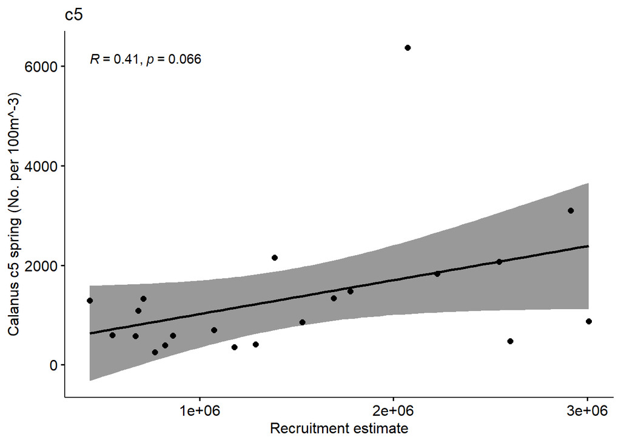

```r
# GB
c5.gb <- calanus %>% filter(epu == 'GB', var == 'c5-Spring')
adult.gb <- calanus %>% filter(epu == 'GB', var == 'adt-Spring' )

df.c5 <- dplyr::full_join(recruit, c5.gb, by = join_by(year)) %>%
  dplyr::select(year, recruit_est, value) %>%
  tidyr::drop_na()
df.adt <- dplyr::full_join(recruit, adult.gb, by = join_by(year)) %>%
  dplyr::select(year, recruit_est, value) %>%
  tidyr::drop_na()

# Regression
ggscatter(df.c5, x = 'recruit_est', y = 'value',
          add = "reg.line", conf.int = TRUE,
          cor.coef = TRUE, cor.method = "pearson",
          xlab = "Recruitment estimate",
          ylab = "Calanus c5 spring (No. per 100m^-3)",
           title = 'c5')
```

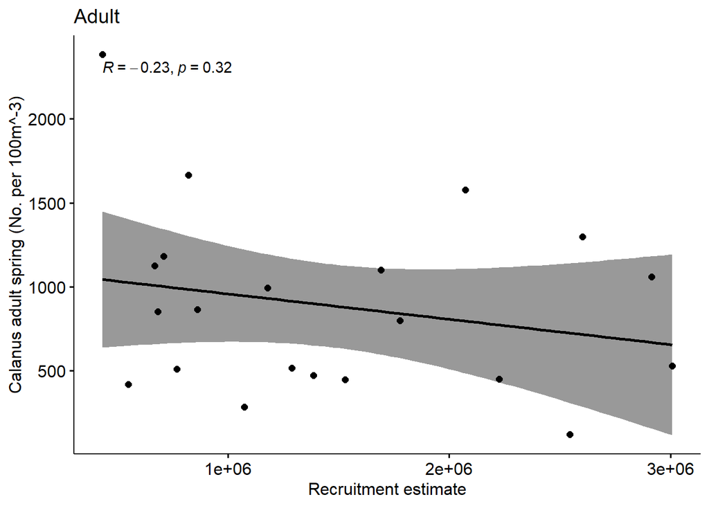

```r
ggscatter(df.adt, x = 'recruit_est', y = 'value',
          add = "reg.line", conf.int = TRUE,
          cor.coef = TRUE, cor.method = "pearson",
          xlab = "Recruitment estimate",
          ylab = "Calanus adult spring (No. per 100m^-3)",
           title = 'Adult')
```

```r
# GLM
eqn <- as.formula(paste('recruit_est ~', paste(colnames(df.c5)[1],
                                               collapse = " + ")))

mod0 <- glm(recruit_est ~ 1,
            data = df.c5,
            family = "poisson")

mod1 <- glm(eqn,
            data = df.c5,
            family = "poisson")

summary(mod0)
```

```
##
## Call:
## glm(formula = recruit_est ~ 1, family = "poisson", data = df.c5)
##
## Coefficients:
##              Estimate Std. Error z value Pr(>|z|)
## (Intercept) 1.420e+01  1.802e-04   78775   <2e-16 ***
## ---
## Signif. codes:  0 '***' 0.001 '**' 0.01 '*' 0.05 '.' 0.1 ' ' 1
##
## (Dispersion parameter for poisson family taken to be 1)
##
##     Null deviance: 8933474  on 20  degrees of freedom
## Residual deviance: 8933474  on 20  degrees of freedom
## AIC: 8933809
##
## Number of Fisher Scoring iterations: 4
```

```r
summary(mod1)
```

```
##
## Call:
## glm(formula = eqn, family = "poisson", data = df.c5)
##
## Coefficients:
##               Estimate Std. Error z value Pr(>|z|)
## (Intercept)  4.350e+01  5.805e-02   749.4   <2e-16 ***
## year        -1.460e-02  2.891e-05  -504.8   <2e-16 ***
## ---
## Signif. codes:  0 '***' 0.001 '**' 0.01 '*' 0.05 '.' 0.1 ' ' 1
##
## (Dispersion parameter for poisson family taken to be 1)
##
##     Null deviance: 8933474  on 20  degrees of freedom
## Residual deviance: 8677368  on 19  degrees of freedom
## AIC: 8677705
##
## Number of Fisher Scoring iterations: 4
```

```r
AIC(mod0, mod1) %>% dplyr::arrange(AIC)
```

```
##      df     AIC
## mod1  2 8677705
## mod0  1 8933809
```

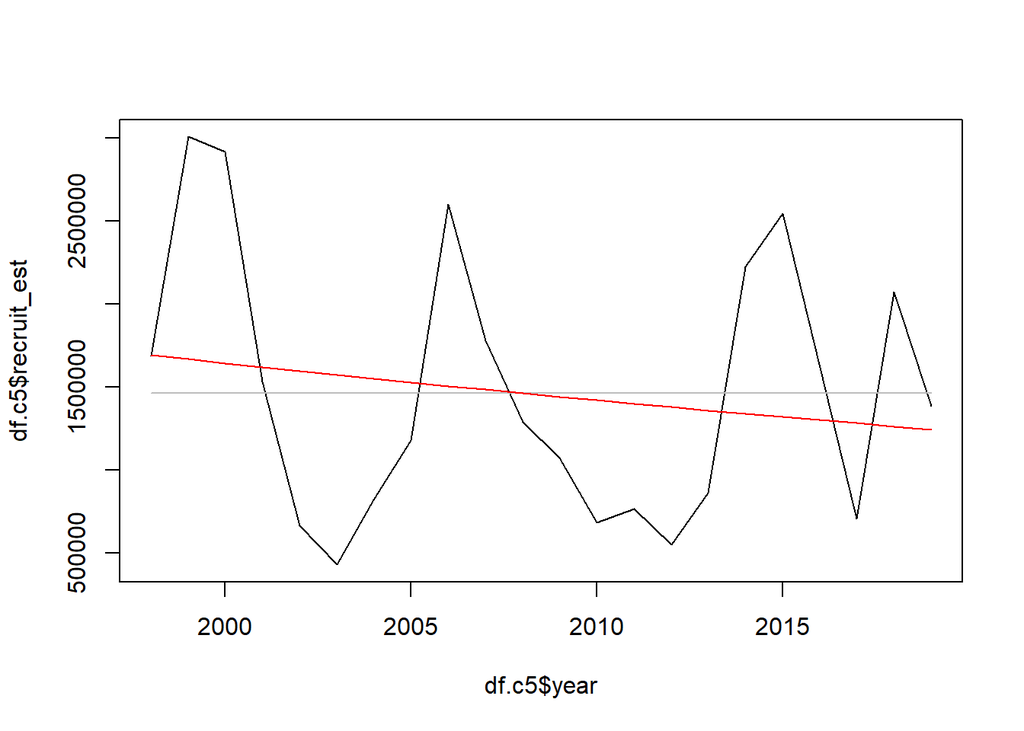

```r
null_prediction <- exp(predict(mod0))
mod_prediction <- exp(predict(mod1))


plot(df.c5$year, df.c5$recruit_est, type = 'l')
lines(df.c5$year, null_prediction, col = "gray")
lines(df.c5$year, mod_prediction, col = "red")
```

Mid-atlantic

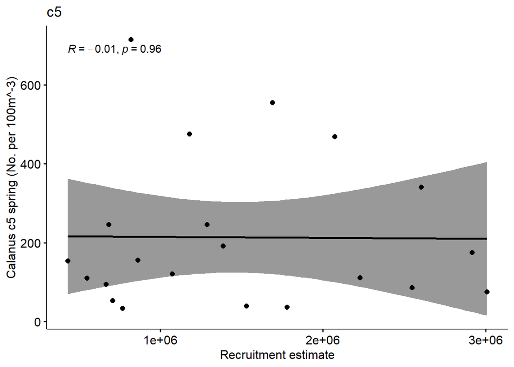

```r
# Mid-Atlantic Bight
c5.mab <- calanus %>% filter(epu == 'MAB', var == 'c5-Spring')
adult.mab <- calanus %>% filter(epu == 'MAB', var == 'adt-Spring' )

df.c5 <- dplyr::full_join(recruit, c5.mab, by = join_by(year)) %>%
  dplyr::select(year, recruit_est, value) %>%
  tidyr::drop_na()
df.adt <- dplyr::full_join(recruit, adult.mab, by = join_by(year)) %>%
  dplyr::select(year, recruit_est, value) %>%
  tidyr::drop_na()

# Regression
ggscatter(df.c5, x = 'recruit_est', y = 'value',
          add = "reg.line", conf.int = TRUE,
          cor.coef = TRUE, cor.method = "pearson",
          xlab = "Recruitment estimate",
          ylab = "Calanus c5 spring (No. per 100m^-3)",
           title = 'c5')
```

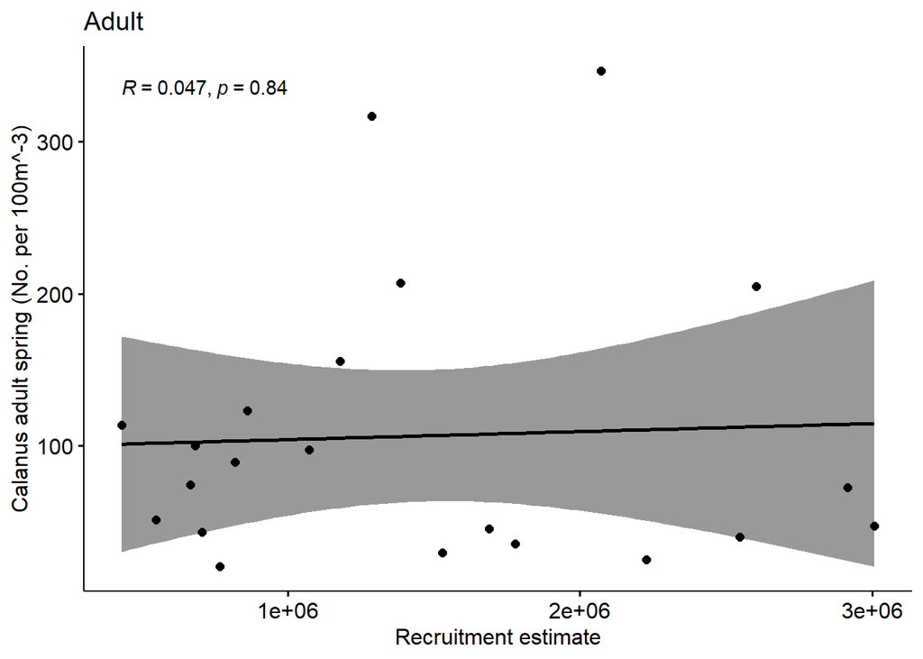

```r
ggscatter(df.adt, x = 'recruit_est', y = 'value',
          add = "reg.line", conf.int = TRUE,
          cor.coef = TRUE, cor.method = "pearson",
          xlab = "Recruitment estimate",
          ylab = "Calanus adult spring (No. per 100m^-3)",
           title = 'Adult')
```

##### Microplankton

```r
micro<-read.csv(here::here('data/phyto_size_class/microplankton_ts_gtf_strata.csv'))
```

```r
# microplankton
```

##### Microplankton analysis

```r
# Microplankton

# micro with year lag
micro.lag <- micro %>%
  mutate(micro_lag1 = lag(weighted_mean_micro,12))

# Join with recruit estimate
micro.rec <- dplyr::full_join(recruit, micro.lag %>%
                   group_by(year) %>%
                   filter(year %in% c(1998:2020)),
dplyr::select(year, month, mean_cpue, mean_micro, weighted_mean_micro, micro_lag1),
                 by = join_by(year))
micro.rec <- micro.rec[-c(1:27),] #removes year < 1998 (starting year for analysis)

#by season
micro_winter <- filter(micro.rec, month %in% c(1,2,3))
micro_winter <- micro_winter[-c(18),] # removes outlier

micro_spring <- filter(micro.rec, month %in% c(4,5,6))
micro_spring <- micro_spring[-c(7),]

micro_summer <- filter(micro.rec, month %in% c(7,8,9))
micro_summer <- micro_summer[-c(17),] #removes outlier

micro_fall <- filter(micro.rec, month %in% c(10,11,12))
micro_fall <- micro_fall[-c(62),] #removes outlier

## One year lag - Summer (peak spawn)
lm_lag<-lm(micro_lag1 ~ recruit_est, data=micro_summer)
summary(lm_lag)
```

```
##
## Call:
## lm(formula = micro_lag1 ~ recruit_est, data = micro_summer)
##
## Residuals:
##       Min        1Q    Median        3Q       Max
## -0.059018 -0.024279 -0.004239  0.013179  0.136674
##
## Coefficients:
##               Estimate Std. Error t value Pr(>|t|)
## (Intercept)  1.102e-01  9.156e-03   12.03   <2e-16 ***
## recruit_est -4.544e-09  5.613e-09   -0.81    0.421
## ---
## Signif. codes:  0 '***' 0.001 '**' 0.01 '*' 0.05 '.' 0.1 ' ' 1
##
## Residual standard error: 0.03558 on 63 degrees of freedom
##   (3 observations deleted due to missingness)
## Multiple R-squared:  0.0103, Adjusted R-squared:  -0.005414
## F-statistic: 0.6554 on 1 and 63 DF,  p-value: 0.4212
```

```r
cor.test(micro_summer$recruit_est, micro_summer$micro_lag1, method=c("pearson"))
```

```
##
##  Pearson's product-moment correlation
##
## data:  micro_summer$recruit_est and micro_summer$micro_lag1
## t = -0.80954, df = 63, p-value = 0.4212
## alternative hypothesis: true correlation is not equal to 0
## 95 percent confidence interval:
##  -0.3370252  0.1460467
## sample estimates:
##        cor
## -0.1014667
```

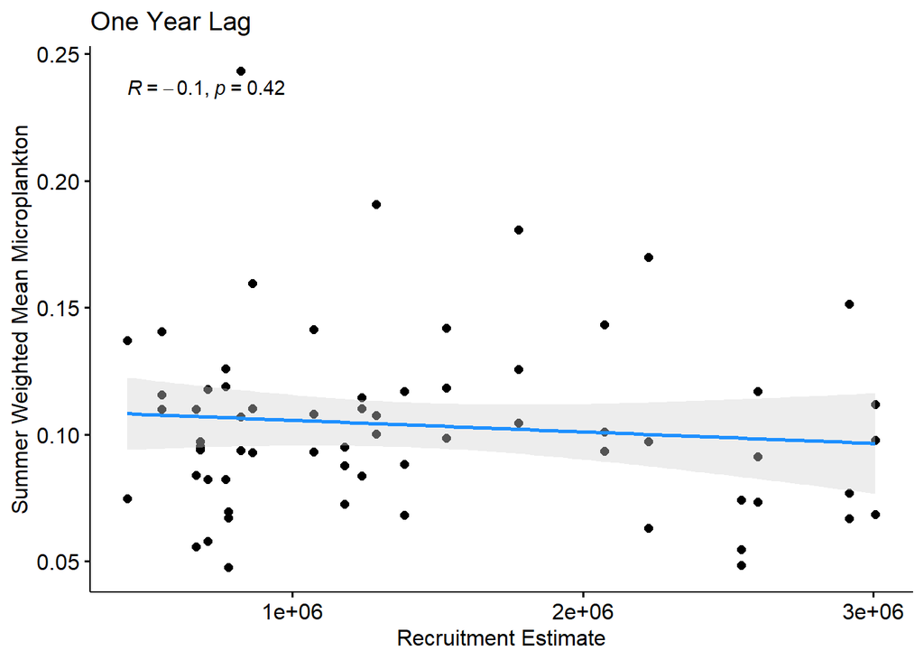

```r
ggscatter(micro_summer, x = "recruit_est", y = "micro_lag1",
          add = "reg.line", conf.int = TRUE,
          cor.coef = TRUE, cor.coeff.args = list(method="pearson"),
          add.params=list(color="dodgerblue", fill="lightgray"),
          xlab = "Recruitment Estimate", ylab = "Summer Weighted Mean Microplankton",
          title="One Year Lag")
```

```r
## Winter
lm_winter<-lm(weighted_mean_micro ~ recruit_est, data=micro_winter)
summary(lm_winter)
```

```
##
## Call:
## lm(formula = weighted_mean_micro ~ recruit_est, data = micro_winter)
##
## Residuals:
##      Min       1Q   Median       3Q      Max
## -0.15902 -0.05443 -0.02121  0.04641  0.24403
##
## Coefficients:
##              Estimate Std. Error t value Pr(>|t|)
## (Intercept) 3.126e-01  2.038e-02  15.337   <2e-16 ***
## recruit_est 1.945e-08  1.247e-08   1.559    0.124
## ---
## Signif. codes:  0 '***' 0.001 '**' 0.01 '*' 0.05 '.' 0.1 ' ' 1
##
## Residual standard error: 0.07927 on 66 degrees of freedom
## Multiple R-squared:  0.03552,    Adjusted R-squared:  0.02091
## F-statistic: 2.431 on 1 and 66 DF,  p-value: 0.1238
```

```r
cor.test(micro_winter$recruit_est, micro_winter$weighted_mean_micro, method=c("pearson"))
```

```
##
##  Pearson's product-moment correlation
##
## data:  micro_winter$recruit_est and micro_winter$weighted_mean_micro
## t = 1.5591, df = 66, p-value = 0.1238
## alternative hypothesis: true correlation is not equal to 0
## 95 percent confidence interval:
##  -0.05230153  0.40854039
## sample estimates:
##       cor
## 0.1884738
```

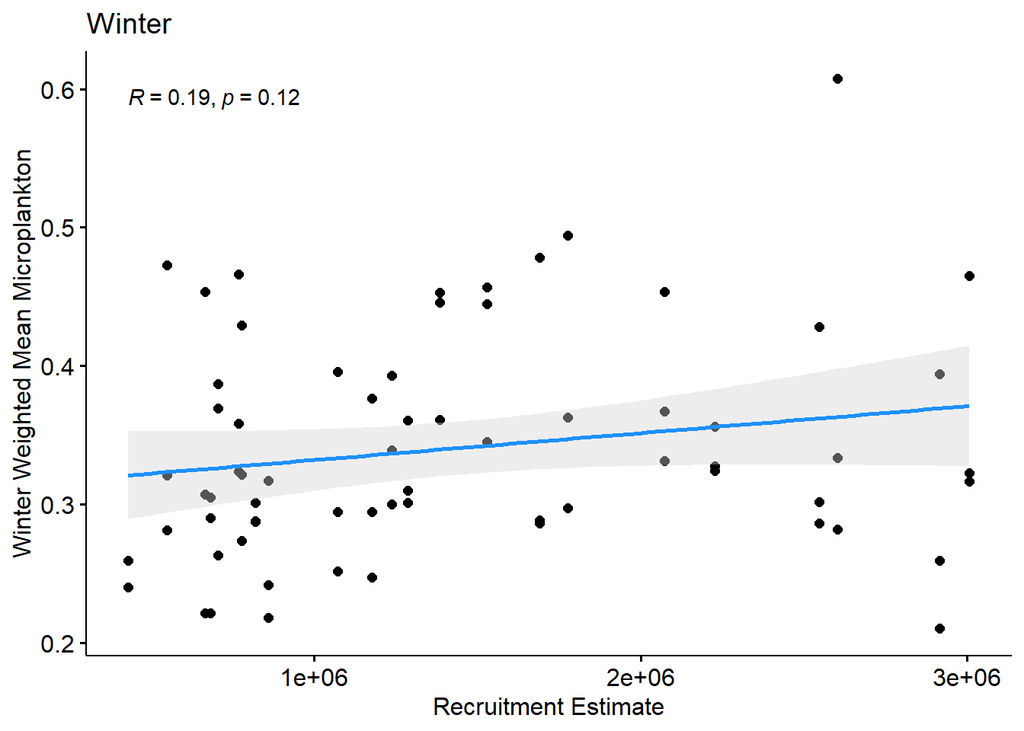

```r
ggscatter(micro_winter, x = "recruit_est", y = "weighted_mean_micro",
          add = "reg.line", conf.int = TRUE,
          cor.coef = TRUE, cor.coeff.args = list(method="pearson"),
          add.params=list(color="dodgerblue", fill="lightgray"),
          xlab = "Recruitment Estimate", ylab = "Winter Weighted Mean Microplankton",
          title="Winter")
```

```r
## Spring
lm_spring<-lm(weighted_mean_micro ~ recruit_est, data=micro_spring)
summary(lm_spring)
```

```
##
## Call:
## lm(formula = weighted_mean_micro ~ recruit_est, data = micro_spring)
##
## Residuals:
##      Min       1Q   Median       3Q      Max
## -0.23260 -0.14253 -0.02222  0.12166  0.36330
##
## Coefficients:
##               Estimate Std. Error t value Pr(>|t|)
## (Intercept)  3.709e-01  3.992e-02   9.289 1.34e-13 ***
## recruit_est -2.326e-08  2.501e-08  -0.930    0.356
## ---
## Signif. codes:  0 '***' 0.001 '**' 0.01 '*' 0.05 '.' 0.1 ' ' 1
##
## Residual standard error: 0.1565 on 66 degrees of freedom
## Multiple R-squared:  0.01293,    Adjusted R-squared:  -0.002025
## F-statistic: 0.8646 on 1 and 66 DF,  p-value: 0.3559
```

```r
cor.test(micro_spring$recruit_est, micro_spring$weighted_mean_micro, method=c("pearson"))
```

```
##
##  Pearson's product-moment correlation
##
## data:  micro_spring$recruit_est and micro_spring$weighted_mean_micro
## t = -0.92982, df = 66, p-value = 0.3559
## alternative hypothesis: true correlation is not equal to 0
## 95 percent confidence interval:
##  -0.3428412  0.1281894
## sample estimates:
##        cor
## -0.1137111
```

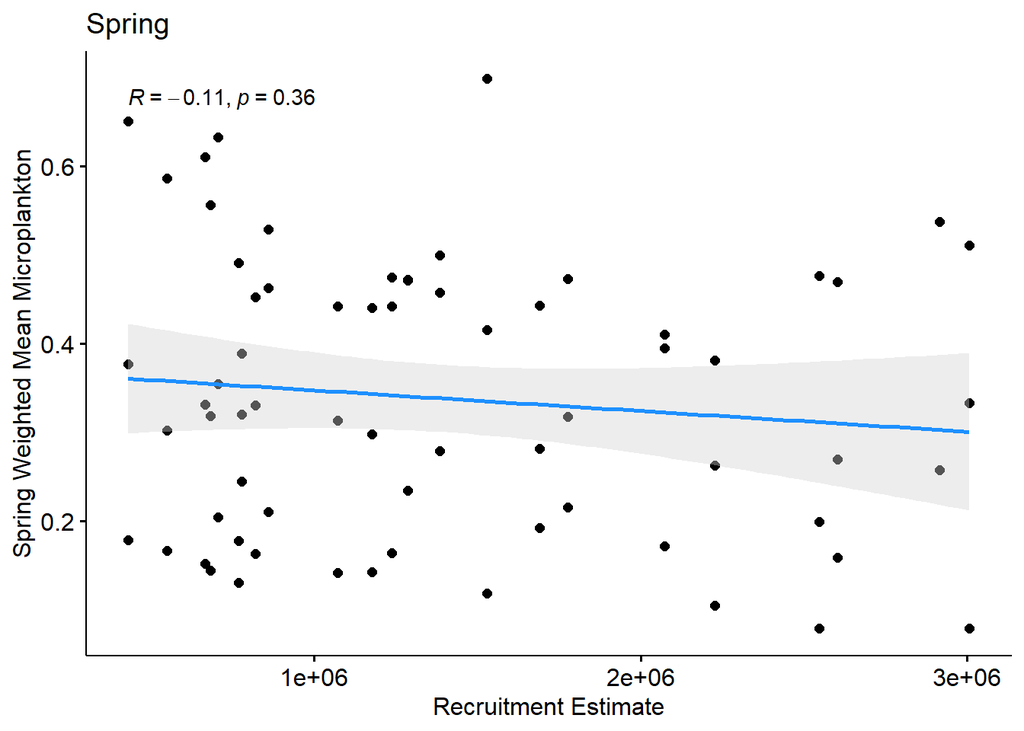

```r
ggscatter(micro_spring, x = "recruit_est", y = "weighted_mean_micro",
          add = "reg.line", conf.int = TRUE,
          cor.coef = TRUE, cor.coeff.args = list(method="pearson"),
          add.params=list(color="dodgerblue", fill="lightgray"),
          xlab = "Recruitment Estimate", ylab = "Spring Weighted Mean Microplankton",
          title="Spring")
```

```r
## Summer
lm_summer<-lm(weighted_mean_micro ~ recruit_est, data=micro_summer)
summary(lm_summer)
```

```
##
## Call:
## lm(formula = weighted_mean_micro ~ recruit_est, data = micro_summer)
##
## Residuals:
##       Min        1Q    Median        3Q       Max
## -0.049815 -0.020294 -0.005428  0.014549  0.091153
##
## Coefficients:
##               Estimate Std. Error t value Pr(>|t|)
## (Intercept)  1.043e-01  7.884e-03  13.224   <2e-16 ***
## recruit_est -2.676e-09  4.825e-09  -0.555    0.581
## ---
## Signif. codes:  0 '***' 0.001 '**' 0.01 '*' 0.05 '.' 0.1 ' ' 1
##
## Residual standard error: 0.03066 on 66 degrees of freedom
## Multiple R-squared:  0.004638,   Adjusted R-squared:  -0.01044
## F-statistic: 0.3075 on 1 and 66 DF,  p-value: 0.5811
```

```r
cor.test(micro_summer$recruit_est, micro_summer$weighted_mean_micro, method=c("pearson"))
```

```
##
##  Pearson's product-moment correlation
##
## data:  micro_summer$recruit_est and micro_summer$weighted_mean_micro
## t = -0.55455, df = 66, p-value = 0.5811
## alternative hypothesis: true correlation is not equal to 0
## 95 percent confidence interval:
##  -0.3016296  0.1731342
## sample estimates:
##         cor
## -0.06810209
```

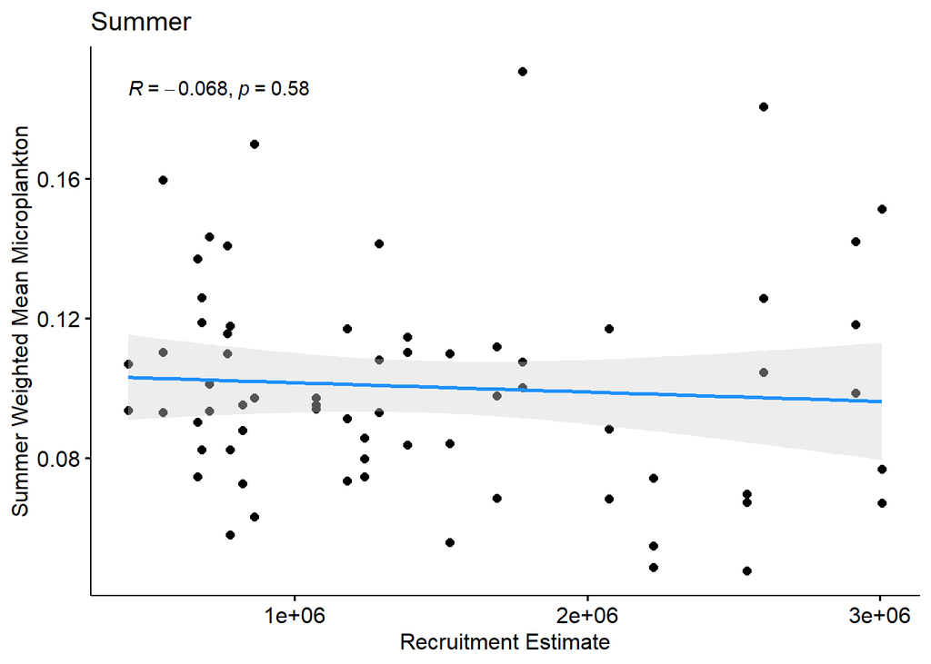

```r
ggscatter(micro_summer, x = "recruit_est", y = "weighted_mean_micro",
          add = "reg.line", conf.int = TRUE,
          cor.coef = TRUE, cor.coeff.args = list(method="pearson"),
          add.params=list(color="dodgerblue", fill="lightgray"),
          xlab = "Recruitment Estimate", ylab = "Summer Weighted Mean Microplankton",
          title="Summer")
```

```r
## Fall
lm_fall<-lm(weighted_mean_micro ~ recruit_est, data=micro_fall)
summary(lm_fall)
```

```
##
## Call:
## lm(formula = weighted_mean_micro ~ recruit_est, data = micro_fall)
##
## Residuals:
##      Min       1Q   Median       3Q      Max
## -0.22693 -0.10823 -0.00688  0.06245  0.48119
##
## Coefficients:
##              Estimate Std. Error t value Pr(>|t|)
## (Intercept) 2.727e-01  3.558e-02   7.665 1.05e-10 ***
## recruit_est 2.725e-08  2.203e-08   1.237     0.22
## ---
## Signif. codes:  0 '***' 0.001 '**' 0.01 '*' 0.05 '.' 0.1 ' ' 1
##
## Residual standard error: 0.141 on 66 degrees of freedom
## Multiple R-squared:  0.02267,    Adjusted R-squared:  0.007858
## F-statistic: 1.531 on 1 and 66 DF,  p-value: 0.2204
```

```r
cor.test(micro_fall$recruit_est, micro_fall$weighted_mean_micro, method=c("pearson"))
```

```
##
##  Pearson's product-moment correlation
##
## data:  micro_fall$recruit_est and micro_fall$weighted_mean_micro
## t = 1.2372, df = 66, p-value = 0.2204
## alternative hypothesis: true correlation is not equal to 0
## 95 percent confidence interval:
##  -0.09114366  0.37549939
## sample estimates:
##       cor
## 0.1505531
```

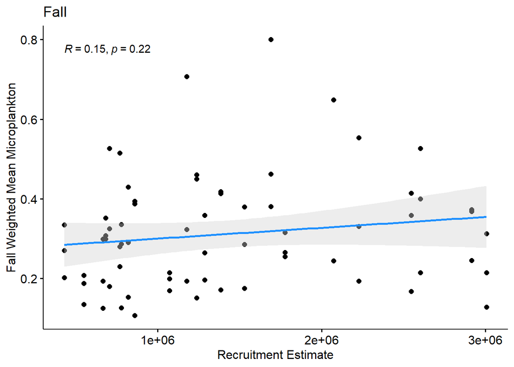

```r
ggscatter(micro_fall, x = "recruit_est", y = "weighted_mean_micro",
          add = "reg.line", conf.int = TRUE,
          cor.coef = TRUE, cor.coeff.args = list(method="pearson"),
          add.params=list(color="dodgerblue", fill="lightgray"),
          xlab = "Recruitment Estimate", ylab = "Fall Weighted Mean Microplankton",
          title="Fall")
```